jupyter nbconvert *.ipynb --to slides --post serve

# Impact of Regional Nutritional on Country's COVID-19 Recovery Rate

## Health Focus Due to Pandemic Observations

### Regional Nutrition

~Observed COVID-19 impact on healthcare workers in my family follow a traditional Eastern Mediterranean diet that includes: Citrus fruits, Almonds, Nigella seeds on cheese or bread, Pistachios, and Pine nuts. Source: https://anjomanfood.com/nuts-in-the-middle-eastern-and-mediterranean-diet/

~Noticed Iran, Saudi Arabia, UAE (travel hub), Egypt, and Pakistan experienced cases with varying medical responses. Eastern Mediterranean region: Afghanistan, Bahrain, Egypt, Iran, Iraq, Jordan, Kuwait, Lebanon, Libya, Morocco, Pakistan, Palestine, Saudi Arabia, Syria, Tunisia, UAE, and Yemen.

~Tracked COVID-19 incidences across WHO maps.

~Excited to test my physican father's theory (and personal diet) out since we were all infected in January-February.

### Healthcare Access

~#1 Key variables to measure healthcare experiencing shortages--in both low and middle-income countries: Ventilator and critical care beds.

~#2 May 6: Iran reached 100,00 COVID-19 cases and still ranked in top 5 globally for over 1 month. Source: https://twitter.com/WHOEMRO/status/1258096811786592256/photo/1

```python
df
```

|  | Country | Alcoholic Beverages | Animal Products | Animal fats | Aquatic Products, Other | Cereals - Excluding Beer | Eggs | Fish, Seafood | Fruits - Excluding Wine | Meat | ... | Vegetable Oils | Vegetables | Obesity | Undernourished | Confirmed | Deaths | Recovered | Active | Population | Unit (all except Population) |
| --- | --- | --- | --- | --- | --- | --- | --- | --- | --- | --- | --- | --- | --- | --- | --- | --- | --- | --- | --- | --- | --- |
| 0 | Afghanistan | 0.0000 | 21.6397 | 6.2224 | 0.0 | 8.0353 | 0.6859 | 0.0327 | 0.4246 | 6.1244 | ... | 17.0831 | 0.3593 | 4.5 | 29.8 | 0.021411 | 0.000492 | 0.002445 | 0.018474 | 38042000.0 | % |
| 1 | Albania | 0.0000 | 32.0002 | 3.4172 | 0.0 | 2.6734 | 1.6448 | 0.1445 | 0.6418 | 8.7428 | ... | 9.2443 | 0.6503 | 22.3 | 6.2 | 0.033730 | 0.001085 | 0.026522 | 0.006123 | 2858000.0 | % |
| 2 | Algeria | 0.0000 | 14.4175 | 0.8972 | 0.0 | 4.2035 | 1.2171 | 0.2008 | 0.5772 | 3.8961 | ... | 27.3606 | 0.5145 | 26.6 | 3.9 | 0.017375 | 0.001309 | 0.009142 | 0.006925 | 43406000.0 | % |
| 3 | Angola | 0.0000 | 15.3041 | 1.3130 | 0.0 | 6.5545 | 0.1539 | 1.4155 | 0.3488 | 11.0268 | ... | 22.4638 | 0.1231 | 6.8 | 25 | 0.000165 | 0.000010 | 0.000054 | 0.000102 | 31427000.0 | % |
| 4 | Antigua and Barbuda | 0.0000 | 27.7033 | 4.6686 | 0.0 | 3.2153 | 0.3872 | 1.5263 | 1.2177 | 14.3202 | ... | 14.4436 | 0.2469 | 19.1 | NaN | 0.025773 | 0.003093 | 0.019588 | 0.003093 | 97000.0 | % |
| ... | ... | ... | ... | ... | ... | ... | ... | ... | ... | ... | ... | ... | ... | ... | ... | ... | ... | ... | ... | ... | ... |
| 165 | Venezuela (Bolivarian Republic of) | 0.0000 | 16.3261 | 2.2673 | 0.0 | 2.5449 | 0.6555 | 0.5707 | 0.9640 | 7.0949 | ... | 29.5211 | 0.1851 | 25.2 | 21.2 | 0.002890 | 0.000035 | 0.000919 | 0.001936 | 28516000.0 | % |
| 166 | Vietnam | 0.0000 | 33.2484 | 3.8238 | 0.0 | 3.7155 | 0.7839 | 1.1217 | 0.4079 | 26.4292 | ... | 5.6211 | 0.6373 | 2.1 | 9.3 | 0.000339 | 0.000000 | 0.000275 | 0.000064 | 95656000.0 | % |
| 167 | Yemen | 0.0000 | 12.5401 | 2.0131 | 0.0 | 11.5271 | 0.5514 | 0.3847 | 0.2564 | 8.0010 | ... | 23.6312 | 0.1667 | 14.1 | 38.9 | 0.000631 | 0.000103 | 0.000017 | 0.000511 | 29162000.0 | % |
| 168 | Zambia | 0.0783 | 9.6005 | 1.6113 | 0.0 | 14.3225 | 0.6266 | 1.0070 | 0.1343 | 4.9010 | ... | 15.2848 | 0.1567 | 6.5 | 46.7 | 0.004658 | 0.000039 | 0.001103 | 0.003516 | 17861000.0 | % |
| 169 | Zimbabwe | 0.0000 | 10.3796 | 2.9543 | 0.0 | 9.7922 | 0.3682 | 0.2455 | 0.0614 | 4.5674 | ... | 26.9396 | 0.0789 | 12.3 | 51.3 | 0.000328 | 0.000027 | 0.000123 | 0.000178 | 14645000.0 | % |

170 rows × 32 columns

```python
df.columns
```

```
Index(['Country', 'Alcoholic Beverages', 'Animal Products', 'Animal fats',
       'Aquatic Products, Other', 'Cereals - Excluding Beer', 'Eggs',
       'Fish, Seafood', 'Fruits - Excluding Wine', 'Meat', 'Miscellaneous',
       'Milk - Excluding Butter', 'Offals', 'Oilcrops', 'Pulses', 'Spices',
       'Starchy Roots', 'Stimulants', 'Sugar Crops', 'Sugar & Sweeteners',
       'Treenuts', 'Vegetal Products', 'Vegetable Oils', 'Vegetables',
       'Obesity', 'Undernourished', 'Confirmed', 'Deaths', 'Recovered',
       'Active', 'Population', 'Unit (all except Population)'],
      dtype='object')
```

## World Health Organization Life Expectancy Data Set

```python
postgres_user = 'dsbc_student'
postgres_pw = '7*.8G9QH21'
postgres_host = '142.93.121.174'
postgres_port = '5432'
postgres_db = 'lifeexpectancy'

engine = create_engine('postgresql://{}:{}@{}:{}/{}'.format(
    postgres_user, postgres_pw, postgres_host, postgres_port, postgres_db))

life_df = pd.read_sql_query('select * from lifeexpectancy',con=engine)

# no need for an open connection,
# as we're only doing a single query
engine.dispose()
```

```python
life_df
```

|  | Country | Year | Status | Life expectancy | Adult Mortality | infant deaths | Alcohol | percentage expenditure | Hepatitis B | Measles | ... | Polio | Total expenditure | Diphtheria | HIV/AIDS | GDP | Population | thinness 1-19 years | thinness 5-9 years | Income composition of resources | Schooling |
| --- | --- | --- | --- | --- | --- | --- | --- | --- | --- | --- | --- | --- | --- | --- | --- | --- | --- | --- | --- | --- | --- |
| 0 | Afghanistan | 2015 | Developing | 65.0 | 263.0 | 62 | 0.01 | 71.279624 | 65.0 | 1154 | ... | 6.0 | 8.16 | 65.0 | 0.1 | 584.259210 | 33736494.0 | 17.2 | 17.3 | 0.479 | 10.1 |
| 1 | Afghanistan | 2014 | Developing | 59.9 | 271.0 | 64 | 0.01 | 73.523582 | 62.0 | 492 | ... | 58.0 | 8.18 | 62.0 | 0.1 | 612.696514 | 327582.0 | 17.5 | 17.5 | 0.476 | 10.0 |
| 2 | Afghanistan | 2013 | Developing | 59.9 | 268.0 | 66 | 0.01 | 73.219243 | 64.0 | 430 | ... | 62.0 | 8.13 | 64.0 | 0.1 | 631.744976 | 31731688.0 | 17.7 | 17.7 | 0.470 | 9.9 |
| 3 | Afghanistan | 2012 | Developing | 59.5 | 272.0 | 69 | 0.01 | 78.184215 | 67.0 | 2787 | ... | 67.0 | 8.52 | 67.0 | 0.1 | 669.959000 | 3696958.0 | 17.9 | 18.0 | 0.463 | 9.8 |
| 4 | Afghanistan | 2011 | Developing | 59.2 | 275.0 | 71 | 0.01 | 7.097109 | 68.0 | 3013 | ... | 68.0 | 7.87 | 68.0 | 0.1 | 63.537231 | 2978599.0 | 18.2 | 18.2 | 0.454 | 9.5 |
| ... | ... | ... | ... | ... | ... | ... | ... | ... | ... | ... | ... | ... | ... | ... | ... | ... | ... | ... | ... | ... | ... |
| 2933 | Zimbabwe | 2004 | Developing | 44.3 | 723.0 | 27 | 4.36 | 0.000000 | 68.0 | 31 | ... | 67.0 | 7.13 | 65.0 | 33.6 | 454.366654 | 12777511.0 | 9.4 | 9.4 | 0.407 | 9.2 |
| 2934 | Zimbabwe | 2003 | Developing | 44.5 | 715.0 | 26 | 4.06 | 0.000000 | 7.0 | 998 | ... | 7.0 | 6.52 | 68.0 | 36.7 | 453.351155 | 12633897.0 | 9.8 | 9.9 | 0.418 | 9.5 |
| 2935 | Zimbabwe | 2002 | Developing | 44.8 | 73.0 | 25 | 4.43 | 0.000000 | 73.0 | 304 | ... | 73.0 | 6.53 | 71.0 | 39.8 | 57.348340 | 125525.0 | 1.2 | 1.3 | 0.427 | 10.0 |
| 2936 | Zimbabwe | 2001 | Developing | 45.3 | 686.0 | 25 | 1.72 | 0.000000 | 76.0 | 529 | ... | 76.0 | 6.16 | 75.0 | 42.1 | 548.587312 | 12366165.0 | 1.6 | 1.7 | 0.427 | 9.8 |
| 2937 | Zimbabwe | 2000 | Developing | 46.0 | 665.0 | 24 | 1.68 | 0.000000 | 79.0 | 1483 | ... | 78.0 | 7.10 | 78.0 | 43.5 | 547.358878 | 12222251.0 | 11.0 | 11.2 | 0.434 | 9.8 |

2938 rows × 22 columns

```python
#df.loc[df['shield'] > 6]
life_df.loc[life_df['Life expectancy '] > 70]
```

|  | Country | Year | Status | Life expectancy | Adult Mortality | infant deaths | Alcohol | percentage expenditure | Hepatitis B | Measles | ... | Polio | Total expenditure | Diphtheria | HIV/AIDS | GDP | Population | thinness 1-19 years | thinness 5-9 years | Income composition of resources | Schooling |
| --- | --- | --- | --- | --- | --- | --- | --- | --- | --- | --- | --- | --- | --- | --- | --- | --- | --- | --- | --- | --- | --- |
| 16 | Albania | 2015 | Developing | 77.8 | 74.0 | 0 | 4.60 | 364.975229 | 99.0 | 0 | ... | 99.0 | 6.00 | 99.0 | 0.1 | 3954.227830 | 28873.0 | 1.2 | 1.3 | 0.762 | 14.2 |
| 17 | Albania | 2014 | Developing | 77.5 | 8.0 | 0 | 4.51 | 428.749067 | 98.0 | 0 | ... | 98.0 | 5.88 | 98.0 | 0.1 | 4575.763787 | 288914.0 | 1.2 | 1.3 | 0.761 | 14.2 |
| 18 | Albania | 2013 | Developing | 77.2 | 84.0 | 0 | 4.76 | 430.876979 | 99.0 | 0 | ... | 99.0 | 5.66 | 99.0 | 0.1 | 4414.723140 | 289592.0 | 1.3 | 1.4 | 0.759 | 14.2 |
| 19 | Albania | 2012 | Developing | 76.9 | 86.0 | 0 | 5.14 | 412.443356 | 99.0 | 9 | ... | 99.0 | 5.59 | 99.0 | 0.1 | 4247.614380 | 2941.0 | 1.3 | 1.4 | 0.752 | 14.2 |
| 20 | Albania | 2011 | Developing | 76.6 | 88.0 | 0 | 5.37 | 437.062100 | 99.0 | 28 | ... | 99.0 | 5.71 | 99.0 | 0.1 | 4437.178680 | 295195.0 | 1.4 | 1.5 | 0.738 | 13.3 |
| ... | ... | ... | ... | ... | ... | ... | ... | ... | ... | ... | ... | ... | ... | ... | ... | ... | ... | ... | ... | ... | ... |
| 2885 | Viet Nam | 2004 | Developing | 74.2 | 136.0 | 29 | 2.86 | 0.000000 | 94.0 | 217 | ... | 96.0 | 5.90 | 96.0 | 0.2 | NaN | NaN | 15.4 | 16.1 | 0.601 | 11.0 |
| 2886 | Viet Nam | 2003 | Developing | 74.0 | 137.0 | 30 | 2.19 | 0.000000 | 78.0 | 2297 | ... | 96.0 | 4.84 | 99.0 | 0.2 | NaN | NaN | 15.6 | 16.2 | 0.592 | 10.9 |
| 2887 | Viet Nam | 2002 | Developing | 73.8 | 137.0 | 30 | 2.03 | 0.000000 | NaN | 6755 | ... | 92.0 | 4.70 | 75.0 | 0.2 | NaN | NaN | 15.6 | 16.3 | 0.584 | 10.7 |
| 2888 | Viet Nam | 2001 | Developing | 73.6 | 138.0 | 32 | 1.84 | 0.000000 | NaN | 12058 | ... | 96.0 | 5.17 | 96.0 | 0.1 | NaN | NaN | 15.7 | 16.4 | 0.576 | 10.6 |
| 2889 | Viet Nam | 2000 | Developing | 73.4 | 139.0 | 33 | 1.60 | 0.000000 | NaN | 16512 | ... | 96.0 | 4.89 | 96.0 | 0.1 | NaN | NaN | 15.8 | 16.4 | 0.569 | 10.4 |

1620 rows × 22 columns

```python
life_df.columns
```

```
Index(['Country', 'Year', 'Status', 'Life expectancy ', 'Adult Mortality',
       'infant deaths', 'Alcohol', 'percentage expenditure', 'Hepatitis B',
       'Measles ', ' BMI ', 'under-five deaths ', 'Polio', 'Total expenditure',
       'Diphtheria ', ' HIV/AIDS', 'GDP', 'Population',
       ' thinness  1-19 years', ' thinness 5-9 years',
       'Income composition of resources', 'Schooling'],
      dtype='object')
```

## Exploratory Data Analysis

1) Join data sets df and life_df to be covid_df. Perform any data cleaning. 2) Explore data to discover relationships and features. We will explore the data using both statistics and data visualization. 3) Perform feature engineering by reviewing the most important variables and transforming into features to predict, classify, or measure our target variable.

### Exploratory Note:

Both data sets include countries as columns, which will serve as the key. However, the 'life_df' set includes multiple years for each country, so we will select the most recent year for each country to join as the key when we append the data sets.

```python
life_df2 = life_df['Year'].max()
life_df2
```

```
2015
```

```python
life_df.nunique()
```

```
Country                             193
Year                                 16
Status                                2
Life expectancy                     362
Adult Mortality                     425
infant deaths                       209
Alcohol                            1076
percentage expenditure             2328
Hepatitis B                          87
Measles                             958
 BMI                                608
under-five deaths                   252
Polio                                73
Total expenditure                   818
Diphtheria                           81
 HIV/AIDS                           200
GDP                                2490
Population                         2278
 thinness  1-19 years               200
 thinness 5-9 years                 207
Income composition of resources     625
Schooling                           173
dtype: int64
```

```python
df.nunique()
```

```
Country                         170
Alcoholic Beverages               3
Animal Products                 170
Animal fats                     169
Aquatic Products, Other           6
Cereals - Excluding Beer        170
Eggs                            169
Fish, Seafood                   170
Fruits - Excluding Wine         168
Meat                            170
Miscellaneous                   137
Milk - Excluding Butter         169
Offals                          167
Oilcrops                        170
Pulses                          160
Spices                          155
Starchy Roots                   166
Stimulants                      169
Sugar Crops                      11
Sugar & Sweeteners                9
Treenuts                        162
Vegetal Products                170
Vegetable Oils                  170
Vegetables                      168
Obesity                         120
Undernourished                   98
Confirmed                       161
Deaths                          145
Recovered                       161
Active                          155
Population                      170
Unit (all except Population)      1
dtype: int64
```

```python
df.columns
```

```
Index(['Country', 'Alcoholic Beverages', 'Animal Products', 'Animal fats',
       'Aquatic Products, Other', 'Cereals - Excluding Beer', 'Eggs',
       'Fish, Seafood', 'Fruits - Excluding Wine', 'Meat', 'Miscellaneous',
       'Milk - Excluding Butter', 'Offals', 'Oilcrops', 'Pulses', 'Spices',
       'Starchy Roots', 'Stimulants', 'Sugar Crops', 'Sugar & Sweeteners',
       'Treenuts', 'Vegetal Products', 'Vegetable Oils', 'Vegetables',
       'Obesity', 'Undernourished', 'Confirmed', 'Deaths', 'Recovered',
       'Active', 'Population', 'Unit (all except Population)'],
      dtype='object')
```

```python
life_df.columns
```

```
Index(['Country', 'Year', 'Status', 'Life expectancy ', 'Adult Mortality',
       'infant deaths', 'Alcohol', 'percentage expenditure', 'Hepatitis B',
       'Measles ', ' BMI ', 'under-five deaths ', 'Polio', 'Total expenditure',
       'Diphtheria ', ' HIV/AIDS', 'GDP', 'Population',
       ' thinness  1-19 years', ' thinness 5-9 years',
       'Income composition of resources', 'Schooling'],
      dtype='object')
```

```python
#Drop less used from first data frame: Alcoholic Beverages, Sugar Crops, Sugar & Sweeteners ,Undernourished, Miscellaneous,Aquatic Products, Other,Undernourished,
df2 = df.drop(['Alcoholic Beverages','Aquatic Products, Other','Sugar & Sweeteners','Sugar Crops','Miscellaneous','Undernourished','Aquatic Products, Other',], axis=1)
df2
```

|  | Country | Animal Products | Animal fats | Cereals - Excluding Beer | Eggs | Fish, Seafood | Fruits - Excluding Wine | Meat | Milk - Excluding Butter | Offals | ... | Vegetal Products | Vegetable Oils | Vegetables | Obesity | Confirmed | Deaths | Recovered | Active | Population | Unit (all except Population) |
| --- | --- | --- | --- | --- | --- | --- | --- | --- | --- | --- | --- | --- | --- | --- | --- | --- | --- | --- | --- | --- | --- |
| 0 | Afghanistan | 21.6397 | 6.2224 | 8.0353 | 0.6859 | 0.0327 | 0.4246 | 6.1244 | 8.2803 | 0.3103 | ... | 28.3684 | 17.0831 | 0.3593 | 4.5 | 0.021411 | 0.000492 | 0.002445 | 0.018474 | 38042000.0 | % |
| 1 | Albania | 32.0002 | 3.4172 | 2.6734 | 1.6448 | 0.1445 | 0.6418 | 8.7428 | 17.7576 | 0.2933 | ... | 17.9998 | 9.2443 | 0.6503 | 22.3 | 0.033730 | 0.001085 | 0.026522 | 0.006123 | 2858000.0 | % |
| 2 | Algeria | 14.4175 | 0.8972 | 4.2035 | 1.2171 | 0.2008 | 0.5772 | 3.8961 | 8.0934 | 0.1067 | ... | 35.5857 | 27.3606 | 0.5145 | 26.6 | 0.017375 | 0.001309 | 0.009142 | 0.006925 | 43406000.0 | % |
| 3 | Angola | 15.3041 | 1.3130 | 6.5545 | 0.1539 | 1.4155 | 0.3488 | 11.0268 | 1.2309 | 0.1539 | ... | 34.7010 | 22.4638 | 0.1231 | 6.8 | 0.000165 | 0.000010 | 0.000054 | 0.000102 | 31427000.0 | % |
| 4 | Antigua and Barbuda | 27.7033 | 4.6686 | 3.2153 | 0.3872 | 1.5263 | 1.2177 | 14.3202 | 6.6607 | 0.1347 | ... | 22.2995 | 14.4436 | 0.2469 | 19.1 | 0.025773 | 0.003093 | 0.019588 | 0.003093 | 97000.0 | % |
| ... | ... | ... | ... | ... | ... | ... | ... | ... | ... | ... | ... | ... | ... | ... | ... | ... | ... | ... | ... | ... | ... |
| 165 | Venezuela (Bolivarian Republic of) | 16.3261 | 2.2673 | 2.5449 | 0.6555 | 0.5707 | 0.9640 | 7.0949 | 5.5217 | 0.2082 | ... | 33.6855 | 29.5211 | 0.1851 | 25.2 | 0.002890 | 0.000035 | 0.000919 | 0.001936 | 28516000.0 | % |
| 166 | Vietnam | 33.2484 | 3.8238 | 3.7155 | 0.7839 | 1.1217 | 0.4079 | 26.4292 | 0.7520 | 0.3378 | ... | 16.7548 | 5.6211 | 0.6373 | 2.1 | 0.000339 | 0.000000 | 0.000275 | 0.000064 | 95656000.0 | % |
| 167 | Yemen | 12.5401 | 2.0131 | 11.5271 | 0.5514 | 0.3847 | 0.2564 | 8.0010 | 1.3463 | 0.2436 | ... | 37.4535 | 23.6312 | 0.1667 | 14.1 | 0.000631 | 0.000103 | 0.000017 | 0.000511 | 29162000.0 | % |
| 168 | Zambia | 9.6005 | 1.6113 | 14.3225 | 0.6266 | 1.0070 | 0.1343 | 4.9010 | 1.2756 | 0.1790 | ... | 40.3939 | 15.2848 | 0.1567 | 6.5 | 0.004658 | 0.000039 | 0.001103 | 0.003516 | 17861000.0 | % |
| 169 | Zimbabwe | 10.3796 | 2.9543 | 9.7922 | 0.3682 | 0.2455 | 0.0614 | 4.5674 | 2.1040 | 0.1315 | ... | 39.6248 | 26.9396 | 0.0789 | 12.3 | 0.000328 | 0.000027 | 0.000123 | 0.000178 | 14645000.0 | % |

170 rows × 26 columns

```python
#Drop less used from second data frame, Life data frame:
life_df2 = life_df.drop(['Measles ','Hepatitis B','infant deaths',' thinness  1-19 years','Alcohol', ' thinness 5-9 years','GDP','Total expenditure'], axis=1)
life_df2
```

|  | Country | Year | Status | Life expectancy | Adult Mortality | percentage expenditure | BMI | under-five deaths | Polio | Diphtheria | HIV/AIDS | Population | Income composition of resources | Schooling |
| --- | --- | --- | --- | --- | --- | --- | --- | --- | --- | --- | --- | --- | --- | --- |
| 0 | Afghanistan | 2015 | Developing | 65.0 | 263.0 | 71.279624 | 19.1 | 83 | 6.0 | 65.0 | 0.1 | 33736494.0 | 0.479 | 10.1 |
| 1 | Afghanistan | 2014 | Developing | 59.9 | 271.0 | 73.523582 | 18.6 | 86 | 58.0 | 62.0 | 0.1 | 327582.0 | 0.476 | 10.0 |
| 2 | Afghanistan | 2013 | Developing | 59.9 | 268.0 | 73.219243 | 18.1 | 89 | 62.0 | 64.0 | 0.1 | 31731688.0 | 0.470 | 9.9 |
| 3 | Afghanistan | 2012 | Developing | 59.5 | 272.0 | 78.184215 | 17.6 | 93 | 67.0 | 67.0 | 0.1 | 3696958.0 | 0.463 | 9.8 |
| 4 | Afghanistan | 2011 | Developing | 59.2 | 275.0 | 7.097109 | 17.2 | 97 | 68.0 | 68.0 | 0.1 | 2978599.0 | 0.454 | 9.5 |
| ... | ... | ... | ... | ... | ... | ... | ... | ... | ... | ... | ... | ... | ... | ... |
| 2933 | Zimbabwe | 2004 | Developing | 44.3 | 723.0 | 0.000000 | 27.1 | 42 | 67.0 | 65.0 | 33.6 | 12777511.0 | 0.407 | 9.2 |
| 2934 | Zimbabwe | 2003 | Developing | 44.5 | 715.0 | 0.000000 | 26.7 | 41 | 7.0 | 68.0 | 36.7 | 12633897.0 | 0.418 | 9.5 |
| 2935 | Zimbabwe | 2002 | Developing | 44.8 | 73.0 | 0.000000 | 26.3 | 40 | 73.0 | 71.0 | 39.8 | 125525.0 | 0.427 | 10.0 |
| 2936 | Zimbabwe | 2001 | Developing | 45.3 | 686.0 | 0.000000 | 25.9 | 39 | 76.0 | 75.0 | 42.1 | 12366165.0 | 0.427 | 9.8 |
| 2937 | Zimbabwe | 2000 | Developing | 46.0 | 665.0 | 0.000000 | 25.5 | 39 | 78.0 | 78.0 | 43.5 | 12222251.0 | 0.434 | 9.8 |

2938 rows × 14 columns

```python
life_df.tail(140)
```

|  | Country | Year | Status | Life expectancy | Adult Mortality | infant deaths | Alcohol | percentage expenditure | Hepatitis B | Measles | ... | Polio | Total expenditure | Diphtheria | HIV/AIDS | GDP | Population | thinness 1-19 years | thinness 5-9 years | Income composition of resources | Schooling |
| --- | --- | --- | --- | --- | --- | --- | --- | --- | --- | --- | --- | --- | --- | --- | --- | --- | --- | --- | --- | --- | --- |
| 2798 | United States of America | 2011 | Developed | 78.7 | 16.0 | 25 | 8.67 | 0.0 | 91.0 | 220 | ... | 94.0 | 17.60 | 96.0 | 0.1 | NaN | NaN | 0.7 | 0.6 | NaN | NaN |
| 2799 | United States of America | 2010 | Developed | 78.7 | 15.0 | 25 | 8.55 | 0.0 | 92.0 | 63 | ... | 93.0 | 17.20 | 95.0 | 0.1 | NaN | NaN | 0.7 | 0.6 | NaN | NaN |
| 2800 | United States of America | 2009 | Developed | 78.5 | 18.0 | 26 | 8.71 | 0.0 | 92.0 | 71 | ... | 93.0 | 17.00 | 95.0 | 0.1 | NaN | NaN | 0.7 | 0.6 | NaN | NaN |
| 2801 | United States of America | 2008 | Developed | 78.2 | 18.0 | 27 | 8.74 | 0.0 | 94.0 | 140 | ... | 94.0 | 16.20 | 96.0 | 0.1 | NaN | NaN | 0.7 | 0.6 | NaN | NaN |
| 2802 | United States of America | 2007 | Developed | 78.1 | 11.0 | 27 | 8.74 | 0.0 | 93.0 | 43 | ... | 93.0 | 15.57 | 96.0 | 0.1 | NaN | NaN | 0.7 | 0.6 | NaN | NaN |
| ... | ... | ... | ... | ... | ... | ... | ... | ... | ... | ... | ... | ... | ... | ... | ... | ... | ... | ... | ... | ... | ... |
| 2933 | Zimbabwe | 2004 | Developing | 44.3 | 723.0 | 27 | 4.36 | 0.0 | 68.0 | 31 | ... | 67.0 | 7.13 | 65.0 | 33.6 | 454.366654 | 12777511.0 | 9.4 | 9.4 | 0.407 | 9.2 |
| 2934 | Zimbabwe | 2003 | Developing | 44.5 | 715.0 | 26 | 4.06 | 0.0 | 7.0 | 998 | ... | 7.0 | 6.52 | 68.0 | 36.7 | 453.351155 | 12633897.0 | 9.8 | 9.9 | 0.418 | 9.5 |
| 2935 | Zimbabwe | 2002 | Developing | 44.8 | 73.0 | 25 | 4.43 | 0.0 | 73.0 | 304 | ... | 73.0 | 6.53 | 71.0 | 39.8 | 57.348340 | 125525.0 | 1.2 | 1.3 | 0.427 | 10.0 |
| 2936 | Zimbabwe | 2001 | Developing | 45.3 | 686.0 | 25 | 1.72 | 0.0 | 76.0 | 529 | ... | 76.0 | 6.16 | 75.0 | 42.1 | 548.587312 | 12366165.0 | 1.6 | 1.7 | 0.427 | 9.8 |
| 2937 | Zimbabwe | 2000 | Developing | 46.0 | 665.0 | 24 | 1.68 | 0.0 | 79.0 | 1483 | ... | 78.0 | 7.10 | 78.0 | 43.5 | 547.358878 | 12222251.0 | 11.0 | 11.2 | 0.434 | 9.8 |

140 rows × 22 columns

### Join datasets by key 'Country'

We will join both dataframes and select only Year == 2015 from the life_df2 dataframe to create a new dataframe: covid_df.

## Univariate Analysis

```python
covid_df.corr()
```

|  | Animal Products | Animal fats | Cereals - Excluding Beer | Eggs | Fish, Seafood | Fruits - Excluding Wine | Meat | Milk - Excluding Butter | Offals | Oilcrops | ... | Adult Mortality | percentage expenditure | BMI | under-five deaths | Polio | Diphtheria | HIV/AIDS | Population_y | Income composition of resources | Schooling |
| --- | --- | --- | --- | --- | --- | --- | --- | --- | --- | --- | --- | --- | --- | --- | --- | --- | --- | --- | --- | --- | --- |
| Animal Products | 1.000000 | 0.696317 | -0.464931 | 0.470419 | -0.021730 | -0.112444 | 0.736699 | 0.634589 | 0.065823 | -0.436742 | ... | -0.401995 | 0.113623 | 0.427160 | -0.204313 | 0.385766 | 0.286291 | -0.374073 | -0.175792 | 0.689126 | 0.616102 |
| Animal fats | 0.696317 | 1.000000 | -0.407189 | 0.281349 | -0.118791 | -0.168326 | 0.231632 | 0.342875 | -0.179648 | -0.340163 | ... | -0.353027 | -0.008614 | 0.369455 | -0.039779 | 0.279839 | 0.239359 | -0.313355 | -0.083317 | 0.594815 | 0.561922 |
| Cereals - Excluding Beer | -0.464931 | -0.407189 | 1.000000 | -0.301811 | -0.041983 | 0.016833 | -0.278022 | -0.276145 | 0.281311 | 0.113556 | ... | 0.400019 | -0.025796 | -0.429014 | 0.174882 | -0.423820 | -0.275711 | 0.511248 | 0.063692 | -0.629482 | -0.569581 |
| Eggs | 0.470419 | 0.281349 | -0.301811 | 1.000000 | 0.206953 | -0.061869 | 0.242745 | 0.273953 | -0.122609 | -0.342333 | ... | -0.369550 | 0.076464 | 0.230078 | -0.109621 | 0.259077 | 0.208234 | -0.381427 | 0.056293 | 0.562982 | 0.457319 |
| Fish, Seafood | -0.021730 | -0.118791 | -0.041983 | 0.206953 | 1.000000 | 0.025822 | 0.015310 | -0.272491 | -0.091862 | 0.346553 | ... | -0.044788 | -0.071822 | -0.130329 | -0.063458 | -0.013412 | -0.044516 | -0.075533 | 0.033109 | 0.003294 | -0.006498 |
| Fruits - Excluding Wine | -0.112444 | -0.168326 | 0.016833 | -0.061869 | 0.025822 | 1.000000 | -0.026609 | -0.062986 | 0.075238 | 0.050115 | ... | 0.027664 | 0.006149 | -0.068760 | -0.039160 | 0.034929 | -0.028214 | -0.047952 | 0.022113 | -0.096971 | -0.061888 |
| Meat | 0.736699 | 0.231632 | -0.278022 | 0.242745 | 0.015310 | -0.026609 | 1.000000 | 0.150011 | 0.229228 | -0.241335 | ... | -0.146436 | -0.019060 | 0.258219 | -0.261477 | 0.223089 | 0.099342 | -0.146077 | -0.189613 | 0.384123 | 0.345947 |
| Milk - Excluding Butter | 0.634589 | 0.342875 | -0.276145 | 0.273953 | -0.272491 | -0.062986 | 0.150011 | 1.000000 | 0.050456 | -0.416321 | ... | -0.340831 | 0.307515 | 0.312060 | -0.064060 | 0.307814 | 0.297828 | -0.302312 | -0.118948 | 0.439168 | 0.371274 |
| Offals | 0.065823 | -0.179648 | 0.281311 | -0.122609 | -0.091862 | 0.075238 | 0.229228 | 0.050456 | 1.000000 | -0.012253 | ... | 0.306247 | 0.120770 | -0.160281 | -0.009059 | -0.184620 | -0.339397 | 0.283079 | -0.036222 | -0.261051 | -0.244990 |
| Oilcrops | -0.436742 | -0.340163 | 0.113556 | -0.342333 | 0.346553 | 0.050115 | -0.241335 | -0.416321 | -0.012253 | 1.000000 | ... | 0.132772 | -0.010549 | -0.212996 | 0.040473 | -0.244861 | -0.186438 | 0.110726 | -0.017289 | -0.377121 | -0.349467 |
| Pulses | -0.425094 | -0.315595 | 0.406925 | -0.331933 | -0.093786 | 0.483089 | -0.318487 | -0.190892 | 0.056014 | 0.149362 | ... | 0.288155 | -0.035522 | -0.351309 | 0.288831 | -0.110936 | -0.118573 | 0.185870 | -0.003634 | -0.511181 | -0.472831 |
| Spices | -0.183738 | -0.200584 | 0.123360 | -0.002724 | 0.226539 | 0.011036 | -0.162154 | -0.084517 | -0.090423 | 0.110913 | ... | 0.058863 | -0.048218 | -0.165202 | 0.138913 | 0.015188 | 0.110768 | -0.040758 | 0.025912 | -0.136138 | -0.138357 |
| Starchy Roots | -0.389973 | -0.303520 | 0.210341 | -0.351431 | 0.169265 | 0.440201 | -0.170990 | -0.387129 | 0.132172 | 0.298163 | ... | 0.420362 | -0.045116 | -0.349777 | 0.145597 | -0.211763 | -0.295134 | 0.302615 | 0.121661 | -0.448664 | -0.341699 |
| Stimulants | 0.507705 | 0.280966 | -0.264135 | 0.278077 | 0.005564 | -0.089096 | 0.306149 | 0.474636 | -0.027747 | -0.286485 | ... | -0.299139 | -0.022776 | 0.246330 | -0.205219 | 0.263951 | 0.226711 | -0.253963 | -0.145858 | 0.455781 | 0.380227 |
| Treenuts | 0.159286 | 0.161809 | -0.205887 | 0.292638 | 0.160767 | -0.091491 | -0.056260 | 0.196338 | -0.146111 | -0.214664 | ... | -0.304072 | 0.022282 | 0.247513 | -0.080001 | 0.193674 | 0.218086 | -0.170558 | 0.024855 | 0.301874 | 0.279961 |
| Vegetal Products | -1.000000 | -0.696306 | 0.464931 | -0.470465 | 0.021678 | 0.112282 | -0.736701 | -0.634573 | -0.065814 | 0.436730 | ... | 0.401972 | -0.113612 | -0.427149 | 0.204334 | -0.385817 | -0.286321 | 0.374038 | 0.175868 | -0.689133 | -0.616118 |
| Vegetable Oils | -0.662161 | -0.369446 | 0.005906 | -0.197051 | -0.249428 | -0.070143 | -0.558249 | -0.361765 | -0.197600 | -0.226120 | ... | 0.218357 | -0.112548 | -0.151018 | 0.133938 | -0.125381 | -0.111301 | 0.159511 | 0.190629 | -0.261272 | -0.221994 |
| Vegetables | 0.083535 | -0.083130 | 0.044259 | 0.164613 | -0.008991 | 0.032403 | 0.003719 | 0.246313 | 0.081951 | -0.131136 | ... | -0.041244 | 0.138704 | 0.037330 | 0.045392 | 0.066256 | 0.063391 | -0.160218 | 0.093412 | 0.034154 | -0.029775 |
| Obesity | 0.430380 | 0.391204 | -0.497187 | 0.309372 | -0.158797 | -0.092355 | 0.271295 | 0.272539 | -0.251688 | -0.157551 | ... | -0.467360 | 0.005017 | 0.770613 | -0.322088 | 0.304861 | 0.298984 | -0.373918 | -0.075649 | 0.692220 | 0.633168 |
| Confirmed | 0.357898 | 0.353236 | -0.362804 | 0.291238 | 0.053155 | -0.056920 | 0.151191 | 0.238475 | -0.171835 | -0.247925 | ... | -0.392181 | -0.040137 | 0.418583 | -0.156785 | 0.261332 | 0.169787 | -0.227340 | -0.017993 | 0.531878 | 0.471506 |
| Deaths | 0.226872 | 0.329210 | -0.295061 | 0.129442 | -0.025360 | -0.065152 | 0.032719 | 0.155998 | -0.173631 | -0.178322 | ... | -0.294966 | -0.029003 | 0.314081 | -0.095783 | 0.170265 | 0.138092 | -0.153854 | 0.021039 | 0.396425 | 0.381687 |
| Recovered | 0.338004 | 0.318047 | -0.288803 | 0.187248 | -0.009306 | -0.048483 | 0.178391 | 0.227385 | -0.145488 | -0.224722 | ... | -0.337419 | -0.024235 | 0.360196 | -0.128309 | 0.211297 | 0.157846 | -0.187125 | -0.007453 | 0.472942 | 0.423891 |
| Active | 0.213949 | 0.214089 | -0.278007 | 0.301388 | 0.121780 | -0.036138 | 0.053351 | 0.138807 | -0.114165 | -0.157233 | ... | -0.270716 | -0.041738 | 0.288604 | -0.120871 | 0.203096 | 0.099637 | -0.171249 | -0.031949 | 0.343856 | 0.292468 |
| Population_x | 0.000845 | 0.019125 | -0.005294 | 0.141391 | -0.012514 | -0.043501 | 0.006982 | -0.053587 | 0.083154 | -0.033425 | ... | -0.009411 | -0.021705 | -0.109352 | 0.687921 | 0.006104 | 0.016436 | -0.044615 | 0.118447 | -0.031850 | -0.041698 |
| Year | NaN | NaN | NaN | NaN | NaN | NaN | NaN | NaN | NaN | NaN | ... | NaN | NaN | NaN | NaN | NaN | NaN | NaN | NaN | NaN | NaN |
| Life expectancy | 0.627147 | 0.538355 | -0.553566 | 0.564881 | 0.046156 | -0.036785 | 0.312417 | 0.435685 | -0.296445 | -0.344197 | ... | -0.769827 | 0.044123 | 0.539841 | -0.270825 | 0.524219 | 0.455457 | -0.611583 | -0.064462 | 0.907585 | 0.819553 |
| Adult Mortality | -0.401995 | -0.353027 | 0.400019 | -0.369550 | -0.044788 | 0.027664 | -0.146436 | -0.340831 | 0.306247 | 0.132772 | ... | 1.000000 | -0.043049 | -0.394249 | 0.209851 | -0.402464 | -0.286336 | 0.664830 | 0.057692 | -0.635897 | -0.532971 |
| percentage expenditure | 0.113623 | -0.008614 | -0.025796 | 0.076464 | -0.071822 | 0.006149 | -0.019060 | 0.307515 | 0.120770 | -0.010549 | ... | -0.043049 | 1.000000 | 0.037973 | -0.015977 | -0.000456 | 0.035585 | -0.038246 | -0.020951 | 0.011441 | 0.014842 |
| BMI | 0.427160 | 0.369455 | -0.429014 | 0.230078 | -0.130329 | -0.068760 | 0.258219 | 0.312060 | -0.160281 | -0.212996 | ... | -0.394249 | 0.037973 | 1.000000 | -0.236015 | 0.288257 | 0.217996 | -0.299818 | -0.006142 | 0.617654 | 0.592342 |
| under-five deaths | -0.204313 | -0.039779 | 0.174882 | -0.109621 | -0.063458 | -0.039160 | -0.261477 | -0.064060 | -0.009059 | 0.040473 | ... | 0.209851 | -0.015977 | -0.236015 | 1.000000 | -0.164226 | -0.153950 | 0.134492 | 0.308069 | -0.247259 | -0.250599 |
| Polio | 0.385766 | 0.279839 | -0.423820 | 0.259077 | -0.013412 | 0.034929 | 0.223089 | 0.307814 | -0.184620 | -0.244861 | ... | -0.402464 | -0.000456 | 0.288257 | -0.164226 | 1.000000 | 0.646003 | -0.433104 | -0.267904 | 0.494363 | 0.409904 |
| Diphtheria | 0.286291 | 0.239359 | -0.275711 | 0.208234 | -0.044516 | -0.028214 | 0.099342 | 0.297828 | -0.339397 | -0.186438 | ... | -0.286336 | 0.035585 | 0.217996 | -0.153950 | 0.646003 | 1.000000 | -0.341930 | -0.081235 | 0.425759 | 0.385533 |
| HIV/AIDS | -0.374073 | -0.313355 | 0.511248 | -0.381427 | -0.075533 | -0.047952 | -0.146077 | -0.302312 | 0.283079 | 0.110726 | ... | 0.664830 | -0.038246 | -0.299818 | 0.134492 | -0.433104 | -0.341930 | 1.000000 | 0.044697 | -0.492405 | -0.393279 |
| Population_y | -0.175792 | -0.083317 | 0.063692 | 0.056293 | 0.033109 | 0.022113 | -0.189613 | -0.118948 | -0.036222 | -0.017289 | ... | 0.057692 | -0.020951 | -0.006142 | 0.308069 | -0.267904 | -0.081235 | 0.044697 | 1.000000 | -0.004053 | 0.012996 |
| Income composition of resources | 0.689126 | 0.594815 | -0.629482 | 0.562982 | 0.003294 | -0.096971 | 0.384123 | 0.439168 | -0.261051 | -0.377121 | ... | -0.635897 | 0.011441 | 0.617654 | -0.247259 | 0.494363 | 0.425759 | -0.492405 | -0.004053 | 1.000000 | 0.926394 |
| Schooling | 0.616102 | 0.561922 | -0.569581 | 0.457319 | -0.006498 | -0.061888 | 0.345947 | 0.371274 | -0.244990 | -0.349467 | ... | -0.532971 | 0.014842 | 0.592342 | -0.250599 | 0.409904 | 0.385533 | -0.393279 | 0.012996 | 0.926394 | 1.000000 |

36 rows × 36 columns

Overview

Dataset info

| Number of variables | 53 |
| --- | --- |
| Number of observations | 157 |
| Total Missing (%) | 0.6% |
| Total size in memory | 66.2 KiB |
| Average record size in memory | 432.0 B |

Variables types

| Numeric | 38 |
| --- | --- |
| Categorical | 2 |
| Boolean | 1 |
| Date | 0 |
| Text (Unique) | 1 |
| Rejected | 11 |
| Unsupported | 0 |

Warnings

- `Aquatic Products, Other` has 153 / 97.5% zeros Zeros

- `Miscellaneous` has 21 / 13.4% zeros Zeros

- `Offals` has 2 / 1.3% zeros Zeros

- `Pulses` has 7 / 4.5% zeros Zeros

- `Spices` has 10 / 6.4% zeros Zeros

- `Stimulants` has 2 / 1.3% zeros Zeros

- `Sugar Crops` has 148 / 94.3% zeros Zeros

- `Sugar & Sweeteners` has 149 / 94.9% zeros Zeros

- `Treenuts` has 8 / 5.1% zeros Zeros

- `Undernourished` has 6 / 3.8% missing values Missing

- `Undernourished` has a high cardinality: 93 distinct values Warning

- `Confirmed` has 6 / 3.8% missing values Missing

- `Deaths` has 6 / 3.8% missing values Missing

- `Deaths` has 14 / 8.9% zeros Zeros

- `Recovered` has 6 / 3.8% missing values Missing

- `Active` has 6 / 3.8% missing values Missing

- `Active` has 5 / 3.2% zeros Zeros

- `Unit (all except Population)` has constant value % Rejected

- `Year` has constant value 2015 Rejected

- `infant deaths` has 50 / 31.8% zeros Zeros

- `Alcohol` is highly correlated with `Life expectancy` (ρ = 0.93813) Rejected

- `percentage expenditure` has 155 / 98.7% zeros Zeros

- `Hepatitis B` has 8 / 5.1% missing values Missing

- `Measles` has 53 / 33.8% zeros Zeros

- `BMI` is highly correlated with `Alcohol` (ρ = 0.95309) Rejected

- `under-five deaths` is highly correlated with `infant deaths` (ρ = 0.99399) Rejected

- `Total expenditure` is highly correlated with `under-five deaths` (ρ = 1) Rejected

- `GDP` has 16 / 10.2% missing values Missing

- `Population_y` is highly correlated with `Total expenditure` (ρ = 1) Rejected

- `thinness 1-19 years` is highly correlated with `Total expenditure` (ρ = 1) Rejected

- `thinness 5-9 years` is highly correlated with `thinness 1-19 years` (ρ = 0.96954) Rejected

- `Income composition of resources` is highly correlated with `Alcohol` (ρ = 0.92907) Rejected

- `Schooling` is highly correlated with `Income composition of resources` (ρ = 0.92639) Rejected

Variables

Country  
Categorical, Unique

| First 3 values |
| --- |
| Mali |
| India |
| Azerbaijan |

| Last 3 values |
| --- |
| Sri Lanka |
| Central African Republic |
| Saudi Arabia |

Toggle details

First 10 values

| Value | Count | Frequency (%) |  |
| --- | --- | --- | --- |
| Afghanistan | 1 | 0.6% |  |
| Albania | 1 | 0.6% |  |
| Algeria | 1 | 0.6% |  |
| Angola | 1 | 0.6% |  |
| Antigua and Barbuda | 1 | 0.6% |  |

Last 10 values

| Value | Count | Frequency (%) |  |
| --- | --- | --- | --- |
| Vanuatu | 1 | 0.6% |  |
| Venezuela (Bolivarian Republic of) | 1 | 0.6% |  |
| Yemen | 1 | 0.6% |  |
| Zambia | 1 | 0.6% |  |
| Zimbabwe | 1 | 0.6% |  |

Alcoholic Beverages  
Boolean

| Distinct count | 2 |
| --- | --- |
| Unique (%) | 1.3% |
| Missing (%) | 0.0% |
| Missing (n) | 0 |

| Mean | 0.00049873 |
| --- | --- |

| 0.0 | 156 |
| --- | --- |
| 0.0783 | 1 |

Toggle details

| Value | Count | Frequency (%) |  |
| --- | --- | --- | --- |
| 0.0 | 156 | 99.4% |  |
| 0.0783 | 1 | 0.6% |  |

Animal Products  
Numeric

| Distinct count | 157 |
| --- | --- |
| Unique (%) | 100.0% |
| Missing (%) | 0.0% |
| Missing (n) | 0 |
| Infinite (%) | 0.0% |
| Infinite (n) | 0 |

| Mean | 20.595 |
| --- | --- |
| Minimum | 5.0182 |
| Maximum | 36.902 |
| Zeros (%) | 0.0% |

Toggle details

**Statistics**

Quantile statistics

| Minimum | 5.0182 |
| --- | --- |
| 5-th percentile | 7.0546 |
| Q1 | 14.418 |
| Median | 20.928 |
| Q3 | 26.91 |
| 95-th percentile | 32.835 |
| Maximum | 36.902 |
| Range | 31.884 |
| Interquartile range | 12.492 |

Descriptive statistics

| Standard deviation | 8.0638 |
| --- | --- |
| Coef of variation | 0.39154 |
| Kurtosis | -0.92571 |
| Mean | 20.595 |
| MAD | 6.8101 |
| Skewness | -0.066656 |
| Sum | 3233.5 |
| Variance | 65.026 |
| Memory size | 7.5 KiB |

**Histogram**

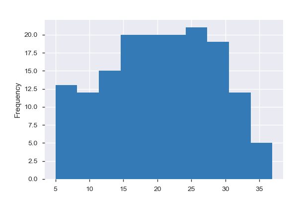

**Common Values**

| Value | Count | Frequency (%) |  |
| --- | --- | --- | --- |
| 10.8323 | 1 | 0.6% |  |
| 25.9903 | 1 | 0.6% |  |
| 28.4111 | 1 | 0.6% |  |
| 26.6163 | 1 | 0.6% |  |
| 17.4631 | 1 | 0.6% |  |
| 32.6886 | 1 | 0.6% |  |
| 19.0932 | 1 | 0.6% |  |
| 25.8451 | 1 | 0.6% |  |
| 26.7378 | 1 | 0.6% |  |
| 20.5571 | 1 | 0.6% |  |
| Other values (147) | 147 | 93.6% |  |

**Extreme Values**

Minimum 5 values

| Value | Count | Frequency (%) |  |
| --- | --- | --- | --- |
| 5.0182 | 1 | 0.6% |  |
| 5.3063 | 1 | 0.6% |  |
| 5.9931 | 1 | 0.6% |  |
| 6.0418 | 1 | 0.6% |  |
| 6.0747 | 1 | 0.6% |  |

Maximum 5 values

| Value | Count | Frequency (%) |  |
| --- | --- | --- | --- |
| 34.1264 | 1 | 0.6% |  |
| 34.4402 | 1 | 0.6% |  |
| 35.4131 | 1 | 0.6% |  |
| 36.725 | 1 | 0.6% |  |
| 36.9018 | 1 | 0.6% |  |

Animal fats  
Numeric

| Distinct count | 156 |
| --- | --- |
| Unique (%) | 99.4% |
| Missing (%) | 0.0% |
| Missing (n) | 0 |
| Infinite (%) | 0.0% |
| Infinite (n) | 0 |

| Mean | 4.1841 |
| --- | --- |
| Minimum | 0.0348 |
| Maximum | 14.937 |
| Zeros (%) | 0.0% |

Toggle details

**Statistics**

Quantile statistics

| Minimum | 0.0348 |
| --- | --- |
| 5-th percentile | 0.53388 |
| Q1 | 1.6113 |
| Median | 3.3013 |
| Q3 | 6.3787 |
| 95-th percentile | 10.556 |
| Maximum | 14.937 |
| Range | 14.902 |
| Interquartile range | 4.7674 |

Descriptive statistics

| Standard deviation | 3.379 |
| --- | --- |
| Coef of variation | 0.80759 |
| Kurtosis | 0.64579 |
| Mean | 4.1841 |
| MAD | 2.7235 |
| Skewness | 1.0943 |
| Sum | 656.9 |
| Variance | 11.418 |
| Memory size | 7.5 KiB |

**Histogram**

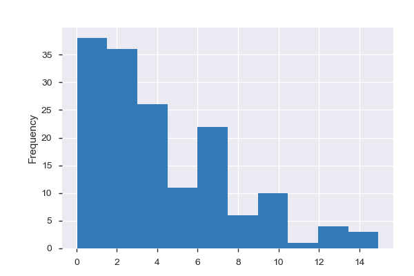

**Common Values**

| Value | Count | Frequency (%) |  |
| --- | --- | --- | --- |
| 3.3076 | 2 | 1.3% |  |
| 1.8698 | 1 | 0.6% |  |
| 0.6241 | 1 | 0.6% |  |
| 2.9392 | 1 | 0.6% |  |
| 6.2224 | 1 | 0.6% |  |
| 6.1 | 1 | 0.6% |  |
| 0.4154 | 1 | 0.6% |  |
| 9.8102 | 1 | 0.6% |  |
| 3.0066 | 1 | 0.6% |  |
| 3.4472 | 1 | 0.6% |  |
| Other values (146) | 146 | 93.0% |  |

**Extreme Values**

Minimum 5 values

| Value | Count | Frequency (%) |  |
| --- | --- | --- | --- |
| 0.0348 | 1 | 0.6% |  |
| 0.1678 | 1 | 0.6% |  |
| 0.2548 | 1 | 0.6% |  |
| 0.3195 | 1 | 0.6% |  |
| 0.33899999999999997 | 1 | 0.6% |  |

Maximum 5 values

| Value | Count | Frequency (%) |  |
| --- | --- | --- | --- |
| 12.6234 | 1 | 0.6% |  |
| 12.8517 | 1 | 0.6% |  |
| 13.9753 | 1 | 0.6% |  |
| 14.2498 | 1 | 0.6% |  |
| 14.9373 | 1 | 0.6% |  |

Aquatic Products, Other  
Numeric

| Distinct count | 5 |
| --- | --- |
| Unique (%) | 3.2% |
| Missing (%) | 0.0% |
| Missing (n) | 0 |
| Infinite (%) | 0.0% |
| Infinite (n) | 0 |

| Mean | 0.00016178 |
| --- | --- |
| Minimum | 0 |
| Maximum | 0.0097 |
| Zeros (%) | 97.5% |

Toggle details

**Statistics**

Quantile statistics

| Minimum | 0 |
| --- | --- |
| 5-th percentile | 0 |
| Q1 | 0 |
| Median | 0 |
| Q3 | 0 |
| 95-th percentile | 0 |
| Maximum | 0.0097 |
| Range | 0.0097 |
| Interquartile range | 0 |

Descriptive statistics

| Standard deviation | 0.0010633 |
| --- | --- |
| Coef of variation | 6.5727 |
| Kurtosis | 53.589 |
| Mean | 0.00016178 |
| MAD | 0.00031532 |
| Skewness | 7.1305 |
| Sum | 0.0254 |
| Variance | 1.1307e-06 |
| Memory size | 2.5 KiB |

**Histogram**

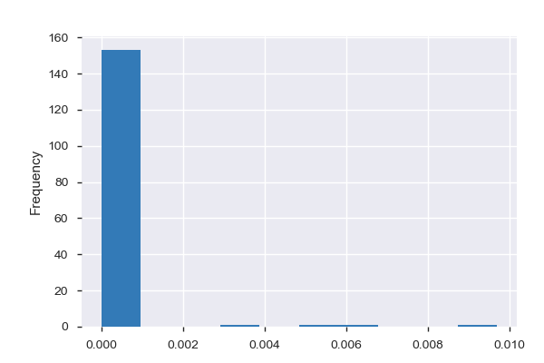

**Common Values**

| Value | Count | Frequency (%) |  |
| --- | --- | --- | --- |
| 0.0 | 153 | 97.5% |  |
| 0.0057 | 1 | 0.6% |  |
| 0.0064 | 1 | 0.6% |  |
| 0.0036 | 1 | 0.6% |  |
| 0.0097 | 1 | 0.6% |  |

**Extreme Values**

Minimum 5 values

| Value | Count | Frequency (%) |  |
| --- | --- | --- | --- |
| 0.0 | 153 | 97.5% |  |
| 0.0036 | 1 | 0.6% |  |
| 0.0057 | 1 | 0.6% |  |
| 0.0064 | 1 | 0.6% |  |
| 0.0097 | 1 | 0.6% |  |

Maximum 5 values

| Value | Count | Frequency (%) |  |
| --- | --- | --- | --- |
| 0.0 | 153 | 97.5% |  |
| 0.0036 | 1 | 0.6% |  |
| 0.0057 | 1 | 0.6% |  |
| 0.0064 | 1 | 0.6% |  |
| 0.0097 | 1 | 0.6% |  |

Cereals - Excluding Beer  
Numeric

| Distinct count | 157 |
| --- | --- |
| Unique (%) | 100.0% |
| Missing (%) | 0.0% |
| Missing (n) | 0 |
| Infinite (%) | 0.0% |
| Infinite (n) | 0 |

| Mean | 4.4243 |
| --- | --- |
| Minimum | 0.9908 |
| Maximum | 18.376 |
| Zeros (%) | 0.0% |

Toggle details

**Statistics**

Quantile statistics

| Minimum | 0.9908 |
| --- | --- |
| 5-th percentile | 1.2728 |
| Q1 | 2.0428 |
| Median | 3.3592 |
| Q3 | 5.6789 |
| 95-th percentile | 10.72 |
| Maximum | 18.376 |
| Range | 17.386 |
| Interquartile range | 3.6361 |

Descriptive statistics

| Standard deviation | 3.1996 |
| --- | --- |
| Coef of variation | 0.72317 |
| Kurtosis | 2.433 |
| Mean | 4.4243 |
| MAD | 2.4375 |
| Skewness | 1.5249 |
| Sum | 694.62 |
| Variance | 10.237 |
| Memory size | 7.5 KiB |

**Histogram**

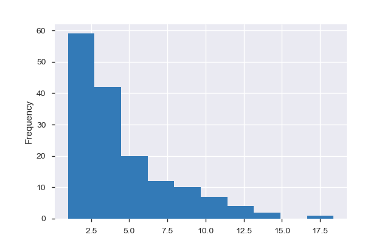

**Common Values**

| Value | Count | Frequency (%) |  |
| --- | --- | --- | --- |
| 4.9807 | 1 | 0.6% |  |
| 4.3092 | 1 | 0.6% |  |
| 13.0891 | 1 | 0.6% |  |
| 1.078 | 1 | 0.6% |  |
| 1.4883 | 1 | 0.6% |  |
| 2.0003 | 1 | 0.6% |  |
| 3.4479 | 1 | 0.6% |  |
| 7.1664 | 1 | 0.6% |  |
| 7.986000000000001 | 1 | 0.6% |  |
| 3.8355 | 1 | 0.6% |  |
| Other values (147) | 147 | 93.6% |  |

**Extreme Values**

Minimum 5 values

| Value | Count | Frequency (%) |  |
| --- | --- | --- | --- |
| 0.9908 | 1 | 0.6% |  |
| 1.078 | 1 | 0.6% |  |
| 1.1241 | 1 | 0.6% |  |
| 1.1278 | 1 | 0.6% |  |
| 1.1778 | 1 | 0.6% |  |

Maximum 5 values

| Value | Count | Frequency (%) |  |
| --- | --- | --- | --- |
| 12.436 | 1 | 0.6% |  |
| 13.0891 | 1 | 0.6% |  |
| 13.4988 | 1 | 0.6% |  |
| 14.3225 | 1 | 0.6% |  |
| 18.3763 | 1 | 0.6% |  |

Eggs  
Numeric

| Distinct count | 156 |
| --- | --- |
| Unique (%) | 99.4% |
| Missing (%) | 0.0% |
| Missing (n) | 0 |
| Infinite (%) | 0.0% |
| Infinite (n) | 0 |

| Mean | 0.95439 |
| --- | --- |
| Minimum | 0.058 |
| Maximum | 3.2756 |
| Zeros (%) | 0.0% |

Toggle details

**Statistics**

Quantile statistics

| Minimum | 0.058 |
| --- | --- |
| 5-th percentile | 0.13722 |
| Q1 | 0.3682 |
| Median | 0.8991 |
| Q3 | 1.2664 |
| 95-th percentile | 2.2859 |
| Maximum | 3.2756 |
| Range | 3.2176 |
| Interquartile range | 0.8982 |

Descriptive statistics

| Standard deviation | 0.65851 |
| --- | --- |
| Coef of variation | 0.68998 |
| Kurtosis | 1.2164 |
| Mean | 0.95439 |
| MAD | 0.51167 |
| Skewness | 1.0108 |
| Sum | 149.84 |
| Variance | 0.43364 |
| Memory size | 7.5 KiB |

**Histogram**

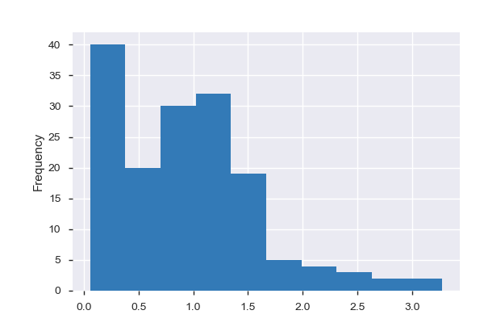

**Common Values**

| Value | Count | Frequency (%) |  |
| --- | --- | --- | --- |
| 0.8991 | 2 | 1.3% |  |
| 0.8448 | 1 | 0.6% |  |
| 0.32899999999999996 | 1 | 0.6% |  |
| 1.3259 | 1 | 0.6% |  |
| 2.4481 | 1 | 0.6% |  |
| 0.825 | 1 | 0.6% |  |
| 1.7484 | 1 | 0.6% |  |
| 0.5249 | 1 | 0.6% |  |
| 0.6203 | 1 | 0.6% |  |
| 1.5706 | 1 | 0.6% |  |
| Other values (146) | 146 | 93.0% |  |

**Extreme Values**

Minimum 5 values

| Value | Count | Frequency (%) |  |
| --- | --- | --- | --- |
| 0.057999999999999996 | 1 | 0.6% |  |
| 0.0701 | 1 | 0.6% |  |
| 0.0744 | 1 | 0.6% |  |
| 0.0746 | 1 | 0.6% |  |
| 0.1074 | 1 | 0.6% |  |

Maximum 5 values

| Value | Count | Frequency (%) |  |
| --- | --- | --- | --- |
| 2.6186 | 1 | 0.6% |  |
| 2.7596 | 1 | 0.6% |  |
| 2.8961 | 1 | 0.6% |  |
| 3.1241 | 1 | 0.6% |  |
| 3.2756 | 1 | 0.6% |  |

Fish, Seafood  
Numeric

| Distinct count | 157 |
| --- | --- |
| Unique (%) | 100.0% |
| Missing (%) | 0.0% |
| Missing (n) | 0 |
| Infinite (%) | 0.0% |
| Infinite (n) | 0 |

| Mean | 0.84838 |
| --- | --- |
| Minimum | 0.0174 |
| Maximum | 8.4068 |
| Zeros (%) | 0.0% |

Toggle details

**Statistics**

Quantile statistics

| Minimum | 0.0174 |
| --- | --- |
| 5-th percentile | 0.09486 |
| Q1 | 0.3245 |
| Median | 0.5708 |
| Q3 | 1.0457 |
| 95-th percentile | 2.3237 |
| Maximum | 8.4068 |
| Range | 8.3894 |
| Interquartile range | 0.7212 |

Descriptive statistics

| Standard deviation | 0.94856 |
| --- | --- |
| Coef of variation | 1.1181 |
| Kurtosis | 26.937 |
| Mean | 0.84838 |
| MAD | 0.58949 |
| Skewness | 4.1429 |
| Sum | 133.19 |
| Variance | 0.89977 |
| Memory size | 7.5 KiB |

**Histogram**

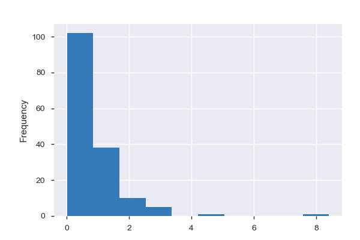

**Common Values**

| Value | Count | Frequency (%) |  |
| --- | --- | --- | --- |
| 0.4515 | 1 | 0.6% |  |
| 0.5746 | 1 | 0.6% |  |
| 0.1302 | 1 | 0.6% |  |
| 3.2666 | 1 | 0.6% |  |
| 0.5633 | 1 | 0.6% |  |
| 0.4514 | 1 | 0.6% |  |
| 0.7451 | 1 | 0.6% |  |
| 0.0962 | 1 | 0.6% |  |
| 1.169 | 1 | 0.6% |  |
| 0.1482 | 1 | 0.6% |  |
| Other values (147) | 147 | 93.6% |  |

**Extreme Values**

Minimum 5 values

| Value | Count | Frequency (%) |  |
| --- | --- | --- | --- |
| 0.0174 | 1 | 0.6% |  |
| 0.0315 | 1 | 0.6% |  |
| 0.0327 | 1 | 0.6% |  |
| 0.0559 | 1 | 0.6% |  |
| 0.0587 | 1 | 0.6% |  |

Maximum 5 values

| Value | Count | Frequency (%) |  |
| --- | --- | --- | --- |
| 2.7774 | 1 | 0.6% |  |
| 3.0833 | 1 | 0.6% |  |
| 3.2666 | 1 | 0.6% |  |
| 4.8461 | 1 | 0.6% |  |
| 8.4068 | 1 | 0.6% |  |

Fruits - Excluding Wine  
Numeric

| Distinct count | 156 |
| --- | --- |
| Unique (%) | 99.4% |
| Missing (%) | 0.0% |
| Missing (n) | 0 |
| Infinite (%) | 0.0% |
| Infinite (n) | 0 |

| Mean | 0.54967 |
| --- | --- |
| Minimum | 0.0373 |
| Maximum | 9.6727 |
| Zeros (%) | 0.0% |

Toggle details

**Statistics**

Quantile statistics

| Minimum | 0.0373 |
| --- | --- |
| 5-th percentile | 0.08512 |
| Q1 | 0.2388 |
| Median | 0.3556 |
| Q3 | 0.5791 |
| 95-th percentile | 1.3878 |
| Maximum | 9.6727 |
| Range | 9.6354 |
| Interquartile range | 0.3403 |

Descriptive statistics

| Standard deviation | 0.86907 |
| --- | --- |
| Coef of variation | 1.5811 |
| Kurtosis | 79.295 |
| Mean | 0.54967 |
| MAD | 0.37635 |
| Skewness | 7.968 |
| Sum | 86.298 |
| Variance | 0.75529 |
| Memory size | 2.5 KiB |

**Histogram**

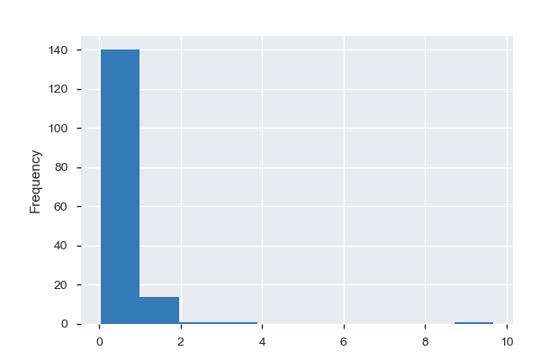

**Common Values**

| Value | Count | Frequency (%) |  |
| --- | --- | --- | --- |
| 0.2987 | 2 | 1.3% |  |
| 1.5030000000000001 | 1 | 0.6% |  |
| 1.2516 | 1 | 0.6% |  |
| 0.0614 | 1 | 0.6% |  |
| 0.7014 | 1 | 0.6% |  |
| 1.2151 | 1 | 0.6% |  |
| 0.5791 | 1 | 0.6% |  |
| 0.1339 | 1 | 0.6% |  |
| 0.2938 | 1 | 0.6% |  |
| 0.3433 | 1 | 0.6% |  |
| Other values (146) | 146 | 93.0% |  |

**Extreme Values**

Minimum 5 values

| Value | Count | Frequency (%) |  |
| --- | --- | --- | --- |
| 0.0373 | 1 | 0.6% |  |
| 0.042 | 1 | 0.6% |  |
| 0.0443 | 1 | 0.6% |  |
| 0.0614 | 1 | 0.6% |  |
| 0.0624 | 1 | 0.6% |  |

Maximum 5 values

| Value | Count | Frequency (%) |  |
| --- | --- | --- | --- |
| 1.6382 | 1 | 0.6% |  |
| 1.6804 | 1 | 0.6% |  |
| 2.8436 | 1 | 0.6% |  |
| 3.6133 | 1 | 0.6% |  |
| 9.6727 | 1 | 0.6% |  |

Meat  
Numeric

| Distinct count | 157 |
| --- | --- |
| Unique (%) | 100.0% |
| Missing (%) | 0.0% |
| Missing (n) | 0 |
| Infinite (%) | 0.0% |
| Infinite (n) | 0 |

| Mean | 9.2145 |
| --- | --- |
| Minimum | 0.9061 |
| Maximum | 22.878 |
| Zeros (%) | 0.0% |

Toggle details

**Statistics**

Quantile statistics

| Minimum | 0.9061 |
| --- | --- |
| 5-th percentile | 2.9911 |
| Q1 | 6.1244 |
| Median | 9.0171 |
| Q3 | 11.558 |
| 95-th percentile | 17.65 |
| Maximum | 22.878 |
| Range | 21.972 |
| Interquartile range | 5.4337 |

Descriptive statistics

| Standard deviation | 4.4521 |
| --- | --- |
| Coef of variation | 0.48317 |
| Kurtosis | 0.31683 |
| Mean | 9.2145 |
| MAD | 3.4562 |
| Skewness | 0.62422 |
| Sum | 1446.7 |
| Variance | 19.822 |
| Memory size | 7.5 KiB |

**Histogram**

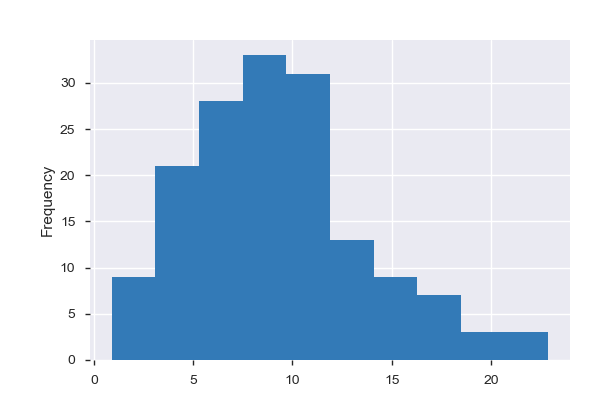

**Common Values**

| Value | Count | Frequency (%) |  |
| --- | --- | --- | --- |
| 3.3685 | 1 | 0.6% |  |
| 11.5581 | 1 | 0.6% |  |
| 9.4166 | 1 | 0.6% |  |
| 8.6212 | 1 | 0.6% |  |
| 9.7764 | 1 | 0.6% |  |
| 11.5636 | 1 | 0.6% |  |
| 2.4838 | 1 | 0.6% |  |
| 9.6514 | 1 | 0.6% |  |
| 6.7594 | 1 | 0.6% |  |
| 2.8993 | 1 | 0.6% |  |
| Other values (147) | 147 | 93.6% |  |

**Extreme Values**

Minimum 5 values

| Value | Count | Frequency (%) |  |
| --- | --- | --- | --- |
| 0.9061 | 1 | 0.6% |  |
| 1.3488 | 1 | 0.6% |  |
| 1.8407 | 1 | 0.6% |  |
| 2.0269999999999997 | 1 | 0.6% |  |
| 2.0412 | 1 | 0.6% |  |

Maximum 5 values

| Value | Count | Frequency (%) |  |
| --- | --- | --- | --- |
| 19.2693 | 1 | 0.6% |  |
| 20.2172 | 1 | 0.6% |  |
| 21.0223 | 1 | 0.6% |  |
| 21.6062 | 1 | 0.6% |  |
| 22.8778 | 1 | 0.6% |  |

Miscellaneous  
Numeric

| Distinct count | 126 |
| --- | --- |
| Unique (%) | 80.3% |
| Missing (%) | 0.0% |
| Missing (n) | 0 |
| Infinite (%) | 0.0% |
| Infinite (n) | 0 |

| Mean | 0.053882 |
| --- | --- |
| Minimum | 0 |
| Maximum | 0.4561 |
| Zeros (%) | 13.4% |

Toggle details

**Statistics**

Quantile statistics

| Minimum | 0 |
| --- | --- |
| 5-th percentile | 0 |
| Q1 | 0.0101 |
| Median | 0.0302 |
| Q3 | 0.0683 |
| 95-th percentile | 0.1639 |
| Maximum | 0.4561 |
| Range | 0.4561 |
| Interquartile range | 0.0582 |

Descriptive statistics

| Standard deviation | 0.069656 |
| --- | --- |
| Coef of variation | 1.2928 |
| Kurtosis | 10.552 |
| Mean | 0.053882 |
| MAD | 0.046846 |
| Skewness | 2.8237 |
| Sum | 8.4594 |
| Variance | 0.0048519 |
| Memory size | 7.5 KiB |

**Histogram**

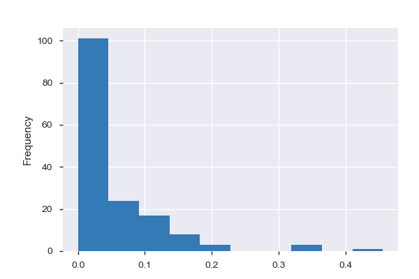

**Common Values**

| Value | Count | Frequency (%) |  |
| --- | --- | --- | --- |
| 0.0 | 21 | 13.4% |  |
| 0.0361 | 3 | 1.9% |  |
| 0.0068 | 2 | 1.3% |  |
| 0.027999999999999997 | 2 | 1.3% |  |
| 0.1012 | 2 | 1.3% |  |
| 0.0622 | 2 | 1.3% |  |
| 0.0138 | 2 | 1.3% |  |
| 0.017 | 2 | 1.3% |  |
| 0.0088 | 2 | 1.3% |  |
| 0.0262 | 2 | 1.3% |  |
| Other values (116) | 117 | 74.5% |  |

**Extreme Values**

Minimum 5 values

| Value | Count | Frequency (%) |  |
| --- | --- | --- | --- |
| 0.0 | 21 | 13.4% |  |
| 0.005 | 1 | 0.6% |  |
| 0.006 | 1 | 0.6% |  |
| 0.0063 | 1 | 0.6% |  |
| 0.0068 | 2 | 1.3% |  |

Maximum 5 values

| Value | Count | Frequency (%) |  |
| --- | --- | --- | --- |
| 0.2258 | 1 | 0.6% |  |
| 0.3235 | 1 | 0.6% |  |
| 0.3244 | 1 | 0.6% |  |
| 0.3556 | 1 | 0.6% |  |
| 0.4561 | 1 | 0.6% |  |

Milk - Excluding Butter  
Numeric

| Distinct count | 156 |
| --- | --- |
| Unique (%) | 99.4% |
| Missing (%) | 0.0% |
| Missing (n) | 0 |
| Infinite (%) | 0.0% |
| Infinite (n) | 0 |

| Mean | 5.2451 |
| --- | --- |
| Minimum | 0.1779 |
| Maximum | 17.758 |
| Zeros (%) | 0.0% |

Toggle details

**Statistics**

Quantile statistics

| Minimum | 0.1779 |
| --- | --- |
| 5-th percentile | 0.56352 |
| Q1 | 2.2937 |
| Median | 5.1279 |
| Q3 | 7.4411 |
| 95-th percentile | 11.056 |
| Maximum | 17.758 |
| Range | 17.58 |
| Interquartile range | 5.1474 |

Descriptive statistics

| Standard deviation | 3.3636 |
| --- | --- |
| Coef of variation | 0.64127 |
| Kurtosis | 0.46226 |
| Mean | 5.2451 |
| MAD | 2.6747 |
| Skewness | 0.65741 |
| Sum | 823.49 |
| Variance | 11.314 |
| Memory size | 7.5 KiB |

**Histogram**

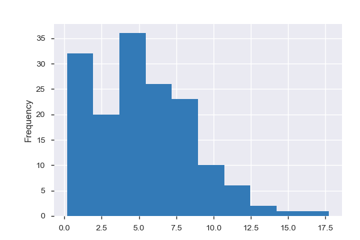

**Common Values**

| Value | Count | Frequency (%) |  |
| --- | --- | --- | --- |
| 5.86 | 2 | 1.3% |  |
| 5.9146 | 1 | 0.6% |  |
| 5.2308 | 1 | 0.6% |  |
| 7.4043 | 1 | 0.6% |  |
| 10.3934 | 1 | 0.6% |  |
| 11.5125 | 1 | 0.6% |  |
| 2.2937 | 1 | 0.6% |  |
| 4.8443 | 1 | 0.6% |  |
| 4.548 | 1 | 0.6% |  |
| 8.3355 | 1 | 0.6% |  |
| Other values (146) | 146 | 93.0% |  |

**Extreme Values**

Minimum 5 values

| Value | Count | Frequency (%) |  |
| --- | --- | --- | --- |
| 0.1779 | 1 | 0.6% |  |
| 0.2243 | 1 | 0.6% |  |
| 0.2438 | 1 | 0.6% |  |
| 0.2553 | 1 | 0.6% |  |
| 0.4024 | 1 | 0.6% |  |

Maximum 5 values

| Value | Count | Frequency (%) |  |
| --- | --- | --- | --- |
| 11.8155 | 1 | 0.6% |  |
| 12.5363 | 1 | 0.6% |  |
| 14.2068 | 1 | 0.6% |  |
| 14.275 | 1 | 0.6% |  |
| 17.7576 | 1 | 0.6% |  |

Offals  
Numeric

| Distinct count | 154 |
| --- | --- |
| Unique (%) | 98.1% |
| Missing (%) | 0.0% |
| Missing (n) | 0 |
| Infinite (%) | 0.0% |
| Infinite (n) | 0 |

| Mean | 0.14842 |
| --- | --- |
| Minimum | 0 |
| Maximum | 0.7268 |
| Zeros (%) | 1.3% |

Toggle details

**Statistics**

Quantile statistics

| Minimum | 0 |
| --- | --- |
| 5-th percentile | 0.01812 |
| Q1 | 0.0763 |
| Median | 0.1221 |
| Q3 | 0.189 |
| 95-th percentile | 0.33644 |
| Maximum | 0.7268 |
| Range | 0.7268 |
| Interquartile range | 0.1127 |

Descriptive statistics

| Standard deviation | 0.11534 |
| --- | --- |
| Coef of variation | 0.77713 |
| Kurtosis | 6.8648 |
| Mean | 0.14842 |
| MAD | 0.081521 |
| Skewness | 2.1107 |
| Sum | 23.302 |
| Variance | 0.013304 |
| Memory size | 2.5 KiB |

**Histogram**

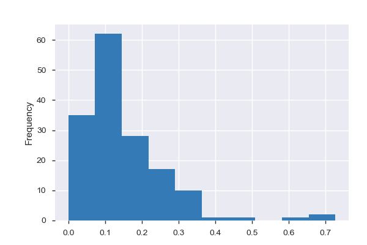

**Common Values**

| Value | Count | Frequency (%) |  |
| --- | --- | --- | --- |
| 0.1563 | 2 | 1.3% |  |
| 0.0 | 2 | 1.3% |  |
| 0.09699999999999999 | 2 | 1.3% |  |
| 0.2145 | 1 | 0.6% |  |
| 0.1 | 1 | 0.6% |  |
| 0.1178 | 1 | 0.6% |  |
| 0.055 | 1 | 0.6% |  |
| 0.2175 | 1 | 0.6% |  |
| 0.0288 | 1 | 0.6% |  |
| 0.1627 | 1 | 0.6% |  |
| Other values (144) | 144 | 91.7% |  |

**Extreme Values**

Minimum 5 values

| Value | Count | Frequency (%) |  |
| --- | --- | --- | --- |
| 0.0 | 2 | 1.3% |  |
| 0.0033 | 1 | 0.6% |  |
| 0.0065 | 1 | 0.6% |  |
| 0.0074 | 1 | 0.6% |  |
| 0.0078 | 1 | 0.6% |  |

Maximum 5 values

| Value | Count | Frequency (%) |  |
| --- | --- | --- | --- |
| 0.4322 | 1 | 0.6% |  |
| 0.4784 | 1 | 0.6% |  |
| 0.5957 | 1 | 0.6% |  |
| 0.6717 | 1 | 0.6% |  |
| 0.7268 | 1 | 0.6% |  |

Oilcrops  
Numeric

| Distinct count | 157 |
| --- | --- |
| Unique (%) | 100.0% |
| Missing (%) | 0.0% |
| Missing (n) | 0 |
| Infinite (%) | 0.0% |
| Infinite (n) | 0 |

| Mean | 3.3572 |
| --- | --- |
| Minimum | 0.064 |
| Maximum | 28.564 |
| Zeros (%) | 0.0% |

Toggle details

**Statistics**

Quantile statistics

| Minimum | 0.064 |
| --- | --- |
| 5-th percentile | 0.35396 |
| Q1 | 0.7686 |
| Median | 1.566 |
| Q3 | 3.4389 |
| 95-th percentile | 12.664 |
| Maximum | 28.564 |
| Range | 28.5 |
| Interquartile range | 2.6703 |

Descriptive statistics

| Standard deviation | 4.8372 |
| --- | --- |
| Coef of variation | 1.4408 |
| Kurtosis | 10.419 |
| Mean | 3.3572 |
| MAD | 3.0245 |
| Skewness | 3.0302 |
| Sum | 527.08 |
| Variance | 23.398 |
| Memory size | 7.5 KiB |

**Histogram**

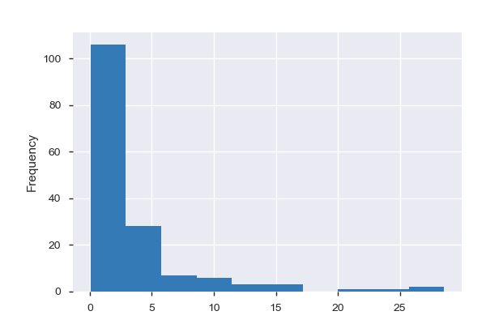

**Common Values**

| Value | Count | Frequency (%) |  |
| --- | --- | --- | --- |
| 0.8931 | 1 | 0.6% |  |
| 1.9462 | 1 | 0.6% |  |
| 3.3157 | 1 | 0.6% |  |
| 1.4978 | 1 | 0.6% |  |
| 13.4216 | 1 | 0.6% |  |
| 3.0787 | 1 | 0.6% |  |
| 3.1993 | 1 | 0.6% |  |
| 3.6545 | 1 | 0.6% |  |
| 0.8909 | 1 | 0.6% |  |
| 0.6488 | 1 | 0.6% |  |
| Other values (147) | 147 | 93.6% |  |

**Extreme Values**

Minimum 5 values

| Value | Count | Frequency (%) |  |
| --- | --- | --- | --- |
| 0.064 | 1 | 0.6% |  |
| 0.0895 | 1 | 0.6% |  |
| 0.1003 | 1 | 0.6% |  |
| 0.1007 | 1 | 0.6% |  |
| 0.1259 | 1 | 0.6% |  |

Maximum 5 values

| Value | Count | Frequency (%) |  |
| --- | --- | --- | --- |
| 16.8666 | 1 | 0.6% |  |
| 20.7704 | 1 | 0.6% |  |
| 23.1779 | 1 | 0.6% |  |
| 27.1892 | 1 | 0.6% |  |
| 28.5639 | 1 | 0.6% |  |

Pulses  
Numeric

| Distinct count | 148 |
| --- | --- |
| Unique (%) | 94.3% |
| Missing (%) | 0.0% |
| Missing (n) | 0 |
| Infinite (%) | 0.0% |
| Infinite (n) | 0 |

| Mean | 0.27069 |
| --- | --- |
| Minimum | 0 |
| Maximum | 2.6909 |
| Zeros (%) | 4.5% |

Toggle details

**Statistics**

Quantile statistics

| Minimum | 0 |
| --- | --- |
| 5-th percentile | 0.00868 |
| Q1 | 0.0427 |
| Median | 0.1483 |
| Q3 | 0.3794 |
| 95-th percentile | 0.85764 |
| Maximum | 2.6909 |
| Range | 2.6909 |
| Interquartile range | 0.3367 |

Descriptive statistics

| Standard deviation | 0.37877 |
| --- | --- |
| Coef of variation | 1.3993 |
| Kurtosis | 18.259 |
| Mean | 0.27069 |
| MAD | 0.24108 |
| Skewness | 3.6127 |
| Sum | 42.498 |
| Variance | 0.14347 |
| Memory size | 7.5 KiB |

**Histogram**

[28 more figures not shown]

Sample

|  | Country | Alcoholic Beverages | Animal Products | Animal fats | Aquatic Products, Other | Cereals - Excluding Beer | Eggs | Fish, Seafood | Fruits - Excluding Wine | Meat | Miscellaneous | Milk - Excluding Butter | Offals | Oilcrops | Pulses | Spices | Starchy Roots | Stimulants | Sugar Crops | Sugar & Sweeteners | Treenuts | Vegetal Products | Vegetable Oils | Vegetables | Obesity | Undernourished | Confirmed | Deaths | Recovered | … |
| --- | --- | --- | --- | --- | --- | --- | --- | --- | --- | --- | --- | --- | --- | --- | --- | --- | --- | --- | --- | --- | --- | --- | --- | --- | --- | --- | --- | --- | --- | --- |
| 0 | Afghanistan | 0.0 | 21.6397 | 6.2224 | 0.0 | 8.0353 | 0.6859 | 0.0327 | 0.4246 | 6.1244 | 0.0163 | 8.2803 | 0.3103 | 1.0452 | 0.1960 | 0.2776 | 0.0490 | 0.0980 | 0.0 | 0.0 | 0.7513 | 28.3684 | 17.0831 | 0.3593 | 4.5 | 29.8 | 0.021411 | 0.000492 | 0.002445 | … |
| 1 | Albania | 0.0 | 32.0002 | 3.4172 | 0.0 | 2.6734 | 1.6448 | 0.1445 | 0.6418 | 8.7428 | 0.0170 | 17.7576 | 0.2933 | 3.1622 | 0.1148 | 0.0000 | 0.0510 | 0.5270 | 0.0 | 0.0 | 0.9181 | 17.9998 | 9.2443 | 0.6503 | 22.3 | 6.2 | 0.033730 | 0.001085 | 0.026522 | … |
| 2 | Algeria | 0.0 | 14.4175 | 0.8972 | 0.0 | 4.2035 | 1.2171 | 0.2008 | 0.5772 | 3.8961 | 0.0439 | 8.0934 | 0.1067 | 1.1983 | 0.2698 | 0.1568 | 0.1129 | 0.2886 | 0.0 | 0.0 | 0.8595 | 35.5857 | 27.3606 | 0.5145 | 26.6 | 3.9 | 0.017375 | 0.001309 | 0.009142 | … |
| 3 | Angola | 0.0 | 15.3041 | 1.3130 | 0.0 | 6.5545 | 0.1539 | 1.4155 | 0.3488 | 11.0268 | 0.0308 | 1.2309 | 0.1539 | 3.9902 | 0.3282 | 0.0103 | 0.7078 | 0.1128 | 0.0 | 0.0 | 0.0308 | 34.7010 | 22.4638 | 0.1231 | 6.8 | 25 | 0.000165 | 0.000010 | 0.000054 | … |
| 4 | Antigua and Barbuda | 0.0 | 27.7033 | 4.6686 | 0.0 | 3.2153 | 0.3872 | 1.5263 | 1.2177 | 14.3202 | 0.0898 | 6.6607 | 0.1347 | 1.3579 | 0.0673 | 0.3591 | 0.0449 | 1.0549 | 0.0 | 0.0 | 0.2020 | 22.2995 | 14.4436 | 0.2469 | 19.1 | NaN | 0.025773 | 0.003093 | 0.019588 | … |

```python
ProfileReport(covid_df)
```

### Analysis Note:

Highly correlated =or Above +/- .5 correlation: Schooling w/'animal fat'

### Indicator of Health Index:

To control for availability of ventilators or other country financed health interventions and infrastructure to deal with health emergencies, like pandemics.

~Index: Global Healthy Security Index https://www.ghsindex.org/wp-content/uploads/2019/10/2019-Global-Health-Security-Index.pdf Although 86% of countries invest local or donor funds in health security, few countries pay for health security gap assessments and action plans out of national budgets. ~Variable: Ventilators

~Variable: Critical Care Beds Saudi Arabia -22.8 per 100,000 (high) Pakistan - 1.5 (lower-middle) Iran - 4.6 (upper-middle medium) Oman - 14.6 (high) Yemen Source: https://www.researchgate.net/figure/Number-of-critical-care-beds-per-100-000-population_fig1_338520008 expenditure health - https://link.springer.com/article/10.1007/s00134-012-2627-8

```python
# Define a dictionary containing Health Index
health_score_data = {'Country': ['United States','United Kingdom', 'Netherlands', 'Australia','Canada','Thailand','Sweden',
                                 'Denmark','South Korea','Finland','France','Slovenia','Switzerland','Germany','Spain','Norway',
                                 'Latvia','Malaysia','Belgium','Portugal','Japan', 'Brazil','Ireland','Singapore','Argentina',
                                 'Austria','Chile','Mexico','Estonia','Indonesia','Italy','Poland','Lithuania','South Africa',
                                 'Hungary','New Zealand','Greece','Croatia','Albania','Turkey','Serbia','Czech Republic','Georgia',
                                 'Armenia','Ecuador','Mongolia','Kyrgyz Republic','Saudi Arabia','Peru','Vietnam','China','Slovakia',
                                 'Philippines','Israel','Kenya','United Arab Emirates','India','Iceland','Kuwait','Romania',
                                 'Bulgaria','Costa Rica','Russia','Uganda','Colombia','El Salvador','Luxembourg','Montenegro','Morocco',
                                 'Panama','Liechtenstein','Myanmar','Laos','Lebanon','Nicaragua','Oman','Cyprus','Moldova',
                                 'Bosnia and Herzegovina','Jordan','Uruguay','Qatar','Kazakhstan','Ethiopia','Bhutan','Madagascar',
                                 'Egypt','Bahrain','Cambodia','North Macedonia','Dominican Republic','Sierra Leone','Zimbabwe','Ukraine',
                                 'Senegal','Nigeria','Iran','Malta','Trinidad and Tobago','Suriname','Tanzania','Bolivia',
                                 'Paraguay','Namibia',"Côte d'Ivoire",'Ghana','Pakistan','Belarus','St. Lucia','Cuba','Liberia','Nepal',
                                 'Bangladesh','Mauritius','Cameroon','Uzbekistan','Azerbaijan','Gambia','Rwanda','Sri Lanka','Maldives',
                                 'Tunisia','St. Vincent and The Grenadines','Micronesia','Guatemala','Guinea','Monaco','Brunei','Togo',
                                 'Afghanistan','Tajikistan','Niger','Barbados','Seychelles','Belize','Turkmenistan', 'Guyana','Haiti',
                                 'Botswana','San Marino','Swaziland','Bahamas','Andorra','Lesotho','Burkina Faso','Cabo Verde',
                                 'Antigua and Barbuda','Jamaica','Mali','Benin','Chad','Zambia','Mozambique','Malawi',
                                 'Papua New Guinea','Honduras','Grenada','Mauritania','Central African Republic','Comoros','Congo','Samoa',
                                 'St. Kitts and Nevis','Sudan','Vanuatu','Timor-Leste','Iraq','Fiji','Libya','Angola','Tonga',
                                 'Dominica','Algeria','Brazzaville','Djibouti','Venezuela','Burundi','Eritrea','Palau','South Sudan','Tuvalu',
                                 'Nauru','Solomon Islands','Niue','Cook Islands','Gabon','Guinea-Bissau','Syria','Kiribati',
                                 'Yemen','Marshall Islands','São Tomé and Príncipe','North Korea','Somalia','Equatorial Guinea'],

        'Health_index': [83.5,77.9,75.6,75.5,75.3,73.2,72.1,70.4,70.2,68.7,68.2,67.2,67.0,66.0,65.9,64.6,62.9,62.2,61.0,
                        60.3,59.8,59.7,59.0,58.7,58.6,58.5,58.3,57.6,57.0,56.6,56.2,55.4,55.0,54.8,54.0,54.0,53.8,53.3,52.9,52.4,
                        52.3,52.0,52.0,50.2,50.1,49.5,49.3,49.3,49.2,49.1,48.2,47.9,47.6,47.3,47.1,46.7,46.5,46.3,46.1,45.8,45.6,
                        45.1,44.3,44.3,44.2,44.2,43.8,43.7,43.7,43.7,43.5,43.4,43.1,43.1,43.1,43.1,43.0,42.9,42.8,42.1,
                        41.3,41.2,40.7,40.6,40.3,40.1,39.9,39.4,39.2,39.1,38.3,38.2,38.2,38.0,37.9,37.8,37.7,37.3,36.6,36.5,36.4,
                        35.8,35.7,35.6,35.5,35.5,35.5,35.3,35.3,35.2,35.1,35.1,35.0,34.9,34.4,34.3,34.2,34.2,34.2,33.9,33.8,33.7,
                        33.0,32.8,32.7,32.7,32.7,32.6,32.5,32.3,32.3,32.2,31.9,31.9,31.8,31.8,31.7,31.5,31.1,31.1,31.1,30.6,30.5,
                        30.2,30.1,29.3,29.0,29.0,29.0,28.8,28.8,28.7,28.1,28.0,27.8,27.6,27.5,27.5,27.3,27.2,26.5,26.4,26.2,26.2,
                        26.1,26.0,25.8,25.7,25.7,25.2,25.1,24.0,23.6,23.6,23.2,23.0,22.8,22.4,21.9,21.7,21.6,20.8,20.7,20.5,
                        20.4,20.0,20.0,19.9,19.2,18.5,18.2,17.7,17.5,16.6,16.2]}

# Convert the dictionary to add into DataFrame
health_df = pd.DataFrame(health_score_data)

# Using DataFrame.insert() to add the column into covid_df
#covid_df.insert(df2["health_score_data"])

#Merge the 2 data sets
merged_df = pd.merge(covid_df, health_df, left_on='Country', right_on='Country')
```

```python
merged_df.columns
```

```
Index(['Country', 'Animal Products', 'Animal fats', 'Cereals - Excluding Beer',
       'Eggs', 'Fish, Seafood', 'Fruits - Excluding Wine', 'Meat',
       'Milk - Excluding Butter', 'Offals', 'Oilcrops', 'Pulses', 'Spices',
       'Starchy Roots', 'Stimulants', 'Treenuts', 'Vegetal Products',
       'Vegetable Oils', 'Vegetables', 'Obesity', 'Confirmed', 'Deaths',
       'Recovered', 'Active', 'Population_x', 'Unit (all except Population)',
       'Year', 'Status', 'Life expectancy ', 'Adult Mortality',
       'percentage expenditure', ' BMI ', 'under-five deaths ', 'Polio',
       'Diphtheria ', ' HIV/AIDS', 'Population_y',
       'Income composition of resources', 'Schooling', 'Health_index'],
      dtype='object')
```

```python
merged_df.loc['United States']
```

[output not shown]

[output cut: 8 more lines]

[output not shown]

## Missing Values

Need to fill in missing values for Percentage Expenditure, BMI, Polio, Treenuts, Pulses, Vegetables,

```python
merged_df.corr()
```

|  | Animal Products | Animal fats | Cereals - Excluding Beer | Eggs | Fish, Seafood | Fruits - Excluding Wine | Meat | Milk - Excluding Butter | Offals | Oilcrops | ... | percentage expenditure | BMI | under-five deaths | Polio | Diphtheria | HIV/AIDS | Population_y | Income composition of resources | Schooling | Health_index |
| --- | --- | --- | --- | --- | --- | --- | --- | --- | --- | --- | --- | --- | --- | --- | --- | --- | --- | --- | --- | --- | --- |
| Animal Products | 1.000000 | 0.710333 | -0.478648 | 0.469318 | -0.022442 | -0.101656 | 0.736385 | 0.641814 | 0.029119 | -0.413549 | ... | 0.118921 | 0.437910 | -0.199489 | 0.398435 | 0.295216 | -0.375809 | -0.180596 | 0.701782 | 0.629505 | 0.515481 |
| Animal fats | 0.710333 | 1.000000 | -0.416339 | 0.262446 | -0.116403 | -0.159390 | 0.251783 | 0.351140 | -0.194524 | -0.329150 | ... | -0.008903 | 0.379134 | -0.036428 | 0.289351 | 0.248572 | -0.317849 | -0.084778 | 0.596489 | 0.563103 | 0.506550 |
| Cereals - Excluding Beer | -0.478648 | -0.416339 | 1.000000 | -0.308149 | -0.054167 | 0.009134 | -0.299150 | -0.272598 | 0.279798 | 0.114859 | ... | -0.028851 | -0.444254 | 0.173847 | -0.423549 | -0.270659 | 0.515659 | 0.060297 | -0.632969 | -0.571845 | -0.444253 |
| Eggs | 0.469318 | 0.262446 | -0.308149 | 1.000000 | 0.223854 | -0.052851 | 0.263722 | 0.261878 | -0.138007 | -0.321104 | ... | 0.077561 | 0.232045 | -0.109087 | 0.274823 | 0.222723 | -0.389517 | 0.057395 | 0.560508 | 0.451998 | 0.458177 |
| Fish, Seafood | -0.022442 | -0.116403 | -0.054167 | 0.223854 | 1.000000 | 0.018571 | -0.006628 | -0.259120 | -0.099272 | 0.346591 | ... | -0.073124 | -0.113074 | -0.062338 | -0.010877 | -0.042181 | -0.077028 | 0.035187 | 0.010264 | 0.001983 | -0.068667 |
| Fruits - Excluding Wine | -0.101656 | -0.159390 | 0.009134 | -0.052851 | 0.018571 | 1.000000 | -0.024509 | -0.047790 | 0.079720 | 0.032919 | ... | 0.006071 | -0.065394 | -0.037703 | 0.037670 | -0.026199 | -0.047501 | 0.023415 | -0.092409 | -0.057522 | -0.104336 |
| Meat | 0.736385 | 0.251783 | -0.299150 | 0.263722 | -0.006628 | -0.024509 | 1.000000 | 0.163367 | 0.209309 | -0.228055 | ... | -0.018125 | 0.273449 | -0.263508 | 0.226785 | 0.094194 | -0.137876 | -0.192964 | 0.405613 | 0.372530 | 0.244104 |
| Milk - Excluding Butter | 0.641814 | 0.351140 | -0.272598 | 0.261878 | -0.259120 | -0.047790 | 0.163367 | 1.000000 | 0.019658 | -0.403036 | ... | 0.321355 | 0.310507 | -0.062141 | 0.325657 | 0.315474 | -0.312569 | -0.122456 | 0.450697 | 0.376794 | 0.343129 |
| Offals | 0.029119 | -0.194524 | 0.279798 | -0.138007 | -0.099272 | 0.079720 | 0.209309 | 0.019658 | 1.000000 | 0.027023 | ... | 0.123583 | -0.180217 | -0.001941 | -0.187155 | -0.346686 | 0.298875 | -0.039800 | -0.271129 | -0.253385 | -0.175541 |
| Oilcrops | -0.413549 | -0.329150 | 0.114859 | -0.321104 | 0.346591 | 0.032919 | -0.228055 | -0.403036 | 0.027023 | 1.000000 | ... | -0.010976 | -0.163590 | 0.038290 | -0.264518 | -0.202584 | 0.109738 | -0.009143 | -0.369430 | -0.344473 | -0.382370 |
| Pulses | -0.419936 | -0.311695 | 0.409971 | -0.327025 | -0.092894 | 0.497729 | -0.320564 | -0.188129 | 0.071100 | 0.145602 | ... | -0.037511 | -0.361713 | 0.280064 | -0.110328 | -0.119864 | 0.172618 | -0.006194 | -0.516880 | -0.477461 | -0.267498 |
| Spices | -0.209950 | -0.194603 | 0.100376 | 0.011249 | 0.221450 | 0.003150 | -0.237087 | -0.062440 | -0.109078 | 0.127786 | ... | -0.049728 | -0.176725 | 0.147135 | 0.015127 | 0.114354 | -0.040463 | 0.023170 | -0.134220 | -0.133312 | -0.087904 |
| Starchy Roots | -0.387591 | -0.302344 | 0.202710 | -0.350042 | 0.172502 | 0.447195 | -0.166073 | -0.395585 | 0.143363 | 0.304605 | ... | -0.046320 | -0.352279 | 0.137222 | -0.212275 | -0.298081 | 0.295374 | 0.120540 | -0.449930 | -0.341704 | -0.321883 |
| Stimulants | 0.495903 | 0.296297 | -0.270974 | 0.289669 | 0.020412 | -0.081584 | 0.290229 | 0.455033 | -0.062976 | -0.274782 | ... | -0.023394 | 0.242331 | -0.204802 | 0.271028 | 0.231936 | -0.257840 | -0.149345 | 0.474446 | 0.394878 | 0.214624 |
| Treenuts | 0.188401 | 0.164782 | -0.253826 | 0.306574 | 0.201834 | -0.098389 | -0.038856 | 0.222835 | -0.181652 | -0.209238 | ... | 0.025898 | 0.238155 | -0.088916 | 0.203553 | 0.230329 | -0.182906 | 0.020511 | 0.318894 | 0.289013 | 0.258659 |
| Vegetal Products | -1.000000 | -0.710321 | 0.478633 | -0.469364 | 0.022396 | 0.101486 | -0.736382 | -0.641805 | -0.029135 | 0.413568 | ... | -0.118908 | -0.437913 | 0.199511 | -0.398488 | -0.295246 | 0.375775 | 0.180667 | -0.701788 | -0.629521 | -0.515501 |
| Vegetable Oils | -0.669238 | -0.389604 | 0.023742 | -0.211264 | -0.240058 | -0.072968 | -0.548870 | -0.385380 | -0.175089 | -0.243485 | ... | -0.116374 | -0.184612 | 0.128582 | -0.126639 | -0.112706 | 0.157890 | 0.190102 | -0.282703 | -0.242394 | -0.127352 |
| Vegetables | 0.071712 | -0.100507 | -0.012157 | 0.183638 | -0.018436 | 0.033612 | -0.026554 | 0.278164 | 0.036590 | -0.126193 | ... | 0.153100 | 0.060095 | 0.054947 | 0.067792 | 0.066522 | -0.165925 | 0.090252 | 0.055665 | -0.016862 | -0.041928 |
| Obesity | 0.435854 | 0.392369 | -0.489569 | 0.291984 | -0.147099 | -0.088428 | 0.290266 | 0.266737 | -0.257126 | -0.119119 | ... | 0.006395 | 0.780198 | -0.327034 | 0.312374 | 0.305877 | -0.375988 | -0.076333 | 0.687399 | 0.627812 | 0.327343 |
| Confirmed | 0.385509 | 0.363431 | -0.358845 | 0.273573 | 0.066726 | -0.053812 | 0.188795 | 0.247044 | -0.147456 | -0.278321 | ... | -0.040638 | 0.440685 | -0.161320 | 0.270600 | 0.173125 | -0.229008 | -0.014421 | 0.536300 | 0.472649 | 0.456909 |
| Deaths | 0.244084 | 0.340994 | -0.296291 | 0.118489 | -0.017931 | -0.065005 | 0.050055 | 0.160422 | -0.159473 | -0.193428 | ... | -0.029572 | 0.310681 | -0.098364 | 0.176261 | 0.142232 | -0.155151 | 0.020222 | 0.399791 | 0.383512 | 0.472358 |
| Recovered | 0.348826 | 0.310547 | -0.294936 | 0.169268 | -0.002495 | -0.044328 | 0.204846 | 0.232973 | -0.144680 | -0.223579 | ... | -0.025195 | 0.363214 | -0.129881 | 0.218277 | 0.163858 | -0.189420 | -0.008604 | 0.472593 | 0.421753 | 0.355128 |
| Active | 0.249087 | 0.241329 | -0.263337 | 0.303952 | 0.148323 | -0.035477 | 0.084228 | 0.144775 | -0.066046 | -0.218805 | ... | -0.042826 | 0.331412 | -0.128972 | 0.213607 | 0.094970 | -0.172642 | -0.022490 | 0.354137 | 0.298410 | 0.347919 |
| Population_x | 0.002143 | 0.017692 | 0.005893 | 0.130911 | -0.005898 | -0.040584 | 0.016784 | -0.062844 | 0.103447 | -0.026496 | ... | -0.021487 | -0.124958 | 0.697445 | 0.003707 | 0.013292 | -0.043567 | 0.119405 | -0.038034 | -0.047860 | 0.091874 |
| Year | NaN | NaN | NaN | NaN | NaN | NaN | NaN | NaN | NaN | NaN | ... | NaN | NaN | NaN | NaN | NaN | NaN | NaN | NaN | NaN | NaN |
| Life expectancy | 0.634044 | 0.539625 | -0.553037 | 0.565338 | 0.055552 | -0.032489 | 0.320719 | 0.442948 | -0.312382 | -0.333776 | ... | 0.045271 | 0.537568 | -0.267914 | 0.534340 | 0.463969 | -0.614532 | -0.065091 | 0.907300 | 0.818421 | 0.650942 |
| Adult Mortality | -0.432882 | -0.369972 | 0.403518 | -0.389155 | -0.046743 | 0.036476 | -0.166003 | -0.369649 | 0.306215 | 0.162789 | ... | -0.044914 | -0.398911 | 0.206128 | -0.412024 | -0.291840 | 0.674491 | 0.056156 | -0.654776 | -0.546813 | -0.413978 |
| percentage expenditure | 0.118921 | -0.008903 | -0.028851 | 0.077561 | -0.073124 | 0.006071 | -0.018125 | 0.321355 | 0.123583 | -0.010976 | ... | 1.000000 | 0.039545 | -0.017123 | 0.003127 | 0.039444 | -0.040954 | -0.021546 | 0.011676 | 0.015139 | 0.051198 |
| BMI | 0.437910 | 0.379134 | -0.444254 | 0.232045 | -0.113074 | -0.065394 | 0.273449 | 0.310507 | -0.180217 | -0.163590 | ... | 0.039545 | 1.000000 | -0.243160 | 0.307705 | 0.233360 | -0.308911 | -0.016152 | 0.628581 | 0.603645 | 0.367911 |
| under-five deaths | -0.199489 | -0.036428 | 0.173847 | -0.109087 | -0.062338 | -0.037703 | -0.263508 | -0.062141 | -0.001941 | 0.038290 | ... | -0.017123 | -0.243160 | 1.000000 | -0.161487 | -0.151832 | 0.126638 | 0.307181 | -0.250177 | -0.253128 | -0.055520 |
| Polio | 0.398435 | 0.289351 | -0.423549 | 0.274823 | -0.010877 | 0.037670 | 0.226785 | 0.325657 | -0.187155 | -0.264518 | ... | 0.003127 | 0.307705 | -0.161487 | 1.000000 | 0.639053 | -0.428879 | -0.265636 | 0.500279 | 0.413611 | 0.369507 |
| Diphtheria | 0.295216 | 0.248572 | -0.270659 | 0.222723 | -0.042181 | -0.026199 | 0.094194 | 0.315474 | -0.346686 | -0.202584 | ... | 0.039444 | 0.233360 | -0.151832 | 0.639053 | 1.000000 | -0.337005 | -0.078368 | 0.430368 | 0.388690 | 0.325217 |
| HIV/AIDS | -0.375809 | -0.317849 | 0.515659 | -0.389517 | -0.077028 | -0.047501 | -0.137876 | -0.312569 | 0.298875 | 0.109738 | ... | -0.040954 | -0.308911 | 0.126638 | -0.428879 | -0.337005 | 1.000000 | 0.042649 | -0.497048 | -0.396047 | -0.302289 |
| Population_y | -0.180596 | -0.084778 | 0.060297 | 0.057395 | 0.035187 | 0.023415 | -0.192964 | -0.122456 | -0.039800 | -0.009143 | ... | -0.021546 | -0.016152 | 0.307181 | -0.265636 | -0.078368 | 0.042649 | 1.000000 | -0.004567 | 0.013002 | 0.135824 |
| Income composition of resources | 0.701782 | 0.596489 | -0.632969 | 0.560508 | 0.010264 | -0.092409 | 0.405613 | 0.450697 | -0.271129 | -0.369430 | ... | 0.011676 | 0.628581 | -0.250177 | 0.500279 | 0.430368 | -0.497048 | -0.004567 | 1.000000 | 0.925844 | 0.696775 |
| Schooling | 0.629505 | 0.563103 | -0.571845 | 0.451998 | 0.001983 | -0.057522 | 0.372530 | 0.376794 | -0.253385 | -0.344473 | ... | 0.015139 | 0.603645 | -0.253128 | 0.413611 | 0.388690 | -0.396047 | 0.013002 | 0.925844 | 1.000000 | 0.700796 |
| Health_index | 0.515481 | 0.506550 | -0.444253 | 0.458177 | -0.068667 | -0.104336 | 0.244104 | 0.343129 | -0.175541 | -0.382370 | ... | 0.051198 | 0.367911 | -0.055520 | 0.369507 | 0.325217 | -0.302289 | 0.135824 | 0.696775 | 0.700796 | 1.000000 |

37 rows × 37 columns

## Decision Tree (Regression)

### Target Variable: Recovery rate = 'Recovered' as continuous value

### Independents: Series of Nutritional Diets

```python
from sklearn import tree
from sklearn.model_selection import train_test_split
from sklearn.tree import DecisionTreeRegressor
from sklearn.metrics import accuracy_score

#X = merged_df[['percentage expenditure',' BMI ','Polio','Treenuts','Pulses','Meat','Vegetables','Health_index']]
#X = merged_df['Treenuts','Health_index'] #Dropping a bunch to check
merged_df_dropped = merged_df.dropna()
# X = merged_df_dropped[['Treenuts', 'Health_index']]
X = merged_df_dropped.drop(columns=['Recovered', 'Country', 'Unit (all except Population)', 'Status', 'Confirmed', 'Population_x', 'Population_y'])
y = merged_df_dropped['Recovered']

#Split data to train and test with 20% sample
X_train, X_test, y_train, y_test = train_test_split(X,y, test_size=.2,random_state =5)

#regressor = DecisionTreeRegressor()
dtr_model = DecisionTreeRegressor(random_state=0)
dtr_model.fit(X_train, y_train)
```

```
DecisionTreeRegressor(criterion='mse', max_depth=None, max_features=None,
                      max_leaf_nodes=None, min_impurity_decrease=0.0,
                      min_impurity_split=None, min_samples_leaf=1,
                      min_samples_split=2, min_weight_fraction_leaf=0.0,
                      presort=False, random_state=0, splitter='best')
```

### Note:

We will identify the most important features in the training set in our Decision Tree Regression model.

```python
print(dtr_model.score(X_train, y_train))
```

```
0.9999981172875818
```

```python
print(dtr_model.score(X_test, y_test))
```

```
0.04605386116160492
```

```python
pd.Series(dtr_model.feature_importances_, index=X_train.columns).sort_values(ascending=False)
```

[output not shown]

### Observation:

We see that our dependent variable of interest "Tree Nuts" did not rank in the top 10. This means it does not have as much significance as we hypothesized.

Run Second Model: Linear Regression Model We will use the same target variable 'Recovered' and the above dependent variables.

### Note:

We will check the score of our Linear Regression model on our test training set.

```python
from sklearn.linear_model import LinearRegression

line = LinearRegression()

line.fit(X_train, y_train)
```

```
LinearRegression(copy_X=True, fit_intercept=True, n_jobs=None, normalize=False)
```

```python
line.score(X_train, y_train)
```

```
0.5114318407634202
```

### Observation:

We see that the score is much lower on our test set. This means that our second model overfit the data to the training set.

```python
line.score(X_test, y_test)
```

```
0.13310347307952053
```

### Note:

Thressholds: Organizing Numerical Values in Diet into Categorical for Comparison

We will set a thresshold of 'Recovery' to 10 percent to see countries that fall into that classifying group.

```python
merged_df[merged_df['Recovered'] <= 0.1]
```

|  | Country | Animal Products | Animal fats | Cereals - Excluding Beer | Eggs | Fish, Seafood | Fruits - Excluding Wine | Meat | Milk - Excluding Butter | Offals | ... | percentage expenditure | BMI | under-five deaths | Polio | Diphtheria | HIV/AIDS | Population_y | Income composition of resources | Schooling | Health_index |
| --- | --- | --- | --- | --- | --- | --- | --- | --- | --- | --- | --- | --- | --- | --- | --- | --- | --- | --- | --- | --- | --- |
| 0 | Afghanistan | 21.6397 | 6.2224 | 8.0353 | 0.6859 | 0.0327 | 0.4246 | 6.1244 | 8.2803 | 0.3103 | ... | 71.279624 | 19.1 | 83 | 6.0 | 65.0 | 0.1 | 33736494.0 | 0.479 | 10.1 | 32.3 |
| 1 | Albania | 32.0002 | 3.4172 | 2.6734 | 1.6448 | 0.1445 | 0.6418 | 8.7428 | 17.7576 | 0.2933 | ... | 364.975229 | 58.0 | 0 | 99.0 | 99.0 | 0.1 | 28873.0 | 0.762 | 14.2 | 52.9 |
| 2 | Algeria | 14.4175 | 0.8972 | 4.2035 | 1.2171 | 0.2008 | 0.5772 | 3.8961 | 8.0934 | 0.1067 | ... | 0.000000 | 59.5 | 24 | 95.0 | 95.0 | 0.1 | 39871528.0 | 0.743 | 14.4 | 23.6 |
| 3 | Angola | 15.3041 | 1.3130 | 6.5545 | 0.1539 | 1.4155 | 0.3488 | 11.0268 | 1.2309 | 0.1539 | ... | 0.000000 | 23.3 | 98 | 7.0 | 64.0 | 1.9 | 2785935.0 | 0.531 | 11.4 | 25.2 |
| 4 | Antigua and Barbuda | 27.7033 | 4.6686 | 3.2153 | 0.3872 | 1.5263 | 1.2177 | 14.3202 | 6.6607 | 0.1347 | ... | 0.000000 | 47.7 | 0 | 86.0 | 99.0 | 0.2 | NaN | 0.784 | 13.9 | 29.0 |
| ... | ... | ... | ... | ... | ... | ... | ... | ... | ... | ... | ... | ... | ... | ... | ... | ... | ... | ... | ... | ... | ... |
| 139 | Uruguay | 25.5069 | 3.4811 | 2.5698 | 1.2804 | 0.3281 | 0.1777 | 12.2841 | 8.0603 | 0.0729 | ... | 0.000000 | 64.0 | 0 | 95.0 | 95.0 | 0.1 | 3431552.0 | 0.794 | 15.5 | 41.3 |
| 140 | Uzbekistan | 25.9903 | 2.4884 | 2.7168 | 1.0639 | 0.0962 | 0.5830 | 10.3624 | 11.8050 | 0.1743 | ... | 0.000000 | 44.7 | 17 | 99.0 | 99.0 | 0.1 | 312989.0 | 0.697 | 12.1 | 34.3 |
| 142 | Yemen | 12.5401 | 2.0131 | 11.5271 | 0.5514 | 0.3847 | 0.2564 | 8.0010 | 1.3463 | 0.2436 | ... | 0.000000 | 41.3 | 47 | 63.0 | 69.0 | 0.1 | NaN | 0.499 | 9.0 | 18.5 |
| 143 | Zambia | 9.6005 | 1.6113 | 14.3225 | 0.6266 | 1.0070 | 0.1343 | 4.9010 | 1.2756 | 0.1790 | ... | 0.000000 | 23.4 | 40 | 9.0 | 9.0 | 4.1 | 161587.0 | 0.576 | 12.5 | 28.7 |
| 144 | Zimbabwe | 10.3796 | 2.9543 | 9.7922 | 0.3682 | 0.2455 | 0.0614 | 4.5674 | 2.1040 | 0.1315 | ... | 0.000000 | 31.8 | 32 | 88.0 | 87.0 | 6.2 | 15777451.0 | 0.507 | 10.3 | 38.2 |

119 rows × 40 columns

## Visualizing 'Recovery Rate Across Eastern Mediterranean Countries'

Hardest Hit Countries Comparison

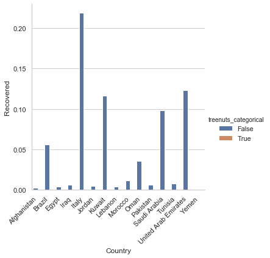

```python
# Goal: To plot countries' recovery rates w/r/t nutritional categories--subclass plotting | Plot counts for each country's recovery rate.
#Doesn't portray sufficiently, USE: sns.countplot(y="Recovered", hue="Country", data=merged_df, palette="Greens_d")
            #plt.show()  for  hue ='treenuts_categorial'
            #sns.catplot(x="Country", y="Recovered", hue='treenuts_categorical', kind="bar",
            #data=merged_df[merged_df['Country'].isin(['Italy','Spain', 'Brazil'])]);
#Inserting top ranked countries w/highest number of COVID-19 cases (Italy, US, and Brazil(more recently))
chart = sns.catplot(x="Country", y="Recovered", hue='treenuts_categorical', kind="bar", data=merged_df[merged_df['Country'].isin(['Italy','United States'
                        , 'Brazil','Iran','Lebanon', 'Afghanistan','Kuwait', 'Pakistan', 'Saudi Arabia','Jordan',
                        'Syria','Yemen','Egypt','United Arab Emirates','Oman','Bahrain','Qatar','Morocco','Libya','Tunisia','Iraq'])]);
chart.set_xticklabels(rotation=45, horizontalalignment='right')
#chart.set_xticklabels(chart.get_xticklabels(x), rotation=45, horizontalalignment='right')
```

### Sorting Eastern Mediterranean Countries

We are curious about a region with a high 'Treenuts' content in their daily diet. So we selected the Eastern Mediterranean region from the World Health Organization grouping.

```python
#merged_df.iloc[[0,40,70,71,77,83,87,103,116,117,133],'Treenuts'].mean()
merged_df[merged_df['Country'].isin(['Lebanon', 'Afghanistan','Kuwait', 'Pakistan', 'Saudi Arabia','Jordan','Syria','Yemen','Egypt','United Arab Emirates','Oman','Bahrain','Qatar','Morocco','Libya','Tunisia','Somalia','Iran','Iraq'])]
```

|  | Country | Animal Products | Animal fats | Cereals - Excluding Beer | Eggs | Fish, Seafood | Fruits - Excluding Wine | Meat | Milk - Excluding Butter | Offals | ... | percentage expenditure | BMI | under-five deaths | Polio | Diphtheria | HIV/AIDS | Population_y | Income composition of resources | Schooling | Health_index |
| --- | --- | --- | --- | --- | --- | --- | --- | --- | --- | --- | --- | --- | --- | --- | --- | --- | --- | --- | --- | --- | --- |
| 0 | Afghanistan | 21.6397 | 6.2224 | 8.0353 | 0.6859 | 0.0327 | 0.4246 | 6.1244 | 8.2803 | 0.3103 | ... | 71.279624 | 19.1 | 83 | 6.0 | 65.0 | 0.1 | 33736494.0 | 0.479 | 10.1 | 32.3 |
| 40 | Egypt | 15.9979 | 3.4231 | 13.4988 | 0.8448 | 1.3200 | 0.7216 | 6.4678 | 3.6343 | 0.2992 | ... | 0.000000 | 61.1 | 60 | 93.0 | 93.0 | 0.1 | NaN | 0.688 | 13.1 | 39.9 |
| 64 | Iraq | 11.1327 | 3.8118 | 6.2761 | 1.9023 | 0.1441 | 0.2306 | 3.5164 | 1.7366 | 0.0288 | ... | 0.000000 | 59.1 | 38 | 63.0 | 58.0 | 0.1 | 36115649.0 | 0.649 | 10.1 | 25.8 |
| 70 | Jordan | 12.2622 | 1.8696 | 3.7391 | 0.5224 | 0.3189 | 0.1980 | 5.8122 | 3.6512 | 0.0880 | ... | 0.000000 | 65.6 | 4 | 99.0 | 99.0 | 0.1 | 915932.0 | 0.741 | 13.1 | 42.1 |
| 74 | Kuwait | 19.8923 | 2.1588 | 3.0847 | 2.3242 | 0.3732 | 0.3496 | 9.5706 | 5.2766 | 0.1890 | ... | 0.000000 | 71.4 | 1 | 99.0 | 99.0 | 0.1 | NaN | 0.799 | 13.3 | 46.1 |
| 76 | Lebanon | 12.4024 | 2.1637 | 2.2530 | 0.3290 | 0.3681 | 0.5800 | 5.1361 | 4.3553 | 0.0502 | ... | 0.000000 | 66.1 | 1 | 75.0 | 81.0 | 0.1 | 5851479.0 | 0.763 | 13.3 | 43.1 |
| 92 | Morocco | 15.4227 | 3.5807 | 7.1539 | 1.1517 | 1.2329 | 0.7014 | 6.9989 | 2.2296 | 0.2289 | ... | 0.000000 | 58.5 | 20 | 99.0 | 99.0 | 0.1 | 3483322.0 | 0.645 | 12.1 | 43.7 |
| 103 | Oman | 23.6146 | 2.3712 | 3.7744 | 1.4422 | 0.9290 | 0.7926 | 9.0171 | 9.6407 | 0.2144 | ... | 0.000000 | 54.6 | 1 | 99.0 | 99.0 | 0.1 | NaN | 0.795 | 13.7 | 43.1 |
| 104 | Pakistan | 24.8245 | 8.9701 | 4.2124 | 0.6203 | 0.0818 | 0.1227 | 3.4967 | 11.5125 | 0.1431 | ... | 0.000000 | 25.4 | 433 | 72.0 | 72.0 | 0.1 | 18938513.0 | 0.548 | 8.1 | 35.5 |
| 114 | Saudi Arabia | 15.3954 | 2.6475 | 5.2126 | 0.9019 | 0.4122 | 0.4219 | 6.9243 | 4.4125 | 0.0970 | ... | 0.000000 | 68.2 | 8 | 97.0 | 98.0 | 0.1 | NaN | 0.845 | 16.1 | 49.3 |
| 133 | Tunisia | 12.7886 | 2.6543 | 3.2543 | 0.9255 | 0.5085 | 0.4068 | 4.0323 | 4.5764 | 0.0915 | ... | 0.000000 | 61.2 | 3 | 98.0 | 98.0 | 0.1 | 11273661.0 | 0.723 | 14.6 | 33.7 |
| 138 | United Arab Emirates | 21.4437 | 4.0036 | 3.0418 | 1.1407 | 0.8108 | 0.6766 | 9.4610 | 5.8600 | 0.1677 | ... | 0.000000 | 64.2 | 1 | 99.0 | 99.0 | 0.1 | NaN | 0.836 | 13.3 | 46.7 |
| 142 | Yemen | 12.5401 | 2.0131 | 11.5271 | 0.5514 | 0.3847 | 0.2564 | 8.0010 | 1.3463 | 0.2436 | ... | 0.000000 | 41.3 | 47 | 63.0 | 69.0 | 0.1 | NaN | 0.499 | 9.0 | 18.5 |

13 rows × 40 columns

# Results:

We see that the Eastern Mediterranean countries included (Afghanistan, Egypt, Iraq, Jordan, Kuwait, Lebanon, Morocco, Oman, Pakistan, Saudi Arabia, Tunisia, United Arab Emirates, and Yemen) present a range between .076 (Yemen) to 3.82 (UAE) regarding 'Treenuts' composite in diet. This range may be attributed to income per capita. Specifically, the lowest end of spectrum is Yemen, a lower-income country, in contrast to the highest end of spectrum UAE, a high-income country. We would need to do a comparative analysis to see if the same trend occurs with this diet in another region and see if income disproportionally affects the consumption of tree nuts.

# Gaps for Further Study:

Upon reflection, we could have controlled for income and its access to nutrition. More specifically, nutrition includes higher-priced food items that are more expensive to transport from mountainous to desert regions. If we were to run a regression model on nutritional items and price, consuming 'Tree nuts' (almonds, pine nuts, hazlenuts, pistachios and walnuts) would present a premium.

To better test the regional nutritional theory positively influencing the COVID-19 recovery rate, we should have sampled the top 10 percent of the population in each Eastern Mediterranean country. Then we would have been better compare the access to high-priced food items, like 'Tree nuts' category, which are more readily available and prepared in higher-priced dishes, like desserts and meat-based rice. These are dishes that populations below the poverty line cannot afford, and thereby cannot easily incorporate into their daily diets to build immunity and ultimately lead to likely recovery--if infected by COVID-19.